# shrimp_goby_boatnoise

Jack L Manera & Jake M Martin

25 February 2025

# 1 📕 READ ME

**🚧 UNPUBLISHED AND ONGOING 🚧**  
The data in this script is currently **unpublished**. There may be part of this script that are currently incomplete. This script has been made publicly available for easy of sharing with collaborators and colleagues who are interested in the progression of the project and for complete transparency.

**SUMMARY**  
Human activities are reshaping marine soundscapes, with boat noise a near-constant source of underwater noise and a primary contributor to rising oceanic noise pollution. Despite increasing concern, empirical data for most marine life, particularly in natural settings, remains sparse. Fish and crustaceans are underrepresented in noise pollution research, despite their auditory ranges make them especially susceptible to low-frequency typical of boat engines. Accordingly, this study employs a field-based experimental approach to investigate the impacts of boat noise on an iconic behavioural mutualism between gobies (Amblyeleotris steinitzi) and shrimp (Alpheus spp). Our findings demonstrate that both species exhibit increased burrow use in response to boat noise, suggesting a heightened perception of risk. Despite the perceived risk triggered by boat noise, the behaviour of the two species remained tightly correlated and communication—measured as antennae contact—remained unchanged. Notably, shrimp exhibited stronger responses to 2-stroke engines, whereas gobies responded more strongly to 4-stroke engines, indicating species-specific sensitivities to different noise spectra. These results highlight the complex and taxon-specific effects of noise pollution on marine species and emphasize the need for targeted research to inform conservation strategies aimed at mitigating anthropogenic acoustic disturbances in marine ecosystems .

**AIM**  
This study employs a field-based experimental approach to investigate the impacts of boat noise on an iconic behavioural mutualism between gobies (Amblyeleotris steinitzi) and shrimp (Alpheus spp). We test the hypothesis that boat noise exposure (2-stroke and 4-stroke engines) would alter the mutualism of these two species by independently altering perceived risk, leading to shifts in behaviour, and potentially disrupting their communication.

**AUTHORS**  
Jack L. Manera<sup>1†</sup>  
Jake M. Martin<sup>1,2,3†</sup>  
Maria M. Palacios<sup>4</sup> Rachel T Mason<sup>3</sup>  
Mark I. McCormick<sup>5</sup>  
Bob BM. Wong<sup>1</sup>

**AFFILIATIONS**  
<sup>1</sup>School of Biological Sciences, Monash University, Clayton, Victoria 3800, Australia  
<sup>2</sup>School of Life and Environmental Sciences, Deakin University, Waurn Ponds, Victoria 3216, Australia  
<sup>3</sup>Department of Wildlife, Fish, and Environmental Studies, Swedish University of Agricultural Sciences, Umeå, Sweden  
<sup>4</sup>Centre for Nature Positive Solutions, School of Science, RMIT University, Melbourne, Victoria 3100, Australia  
<sup>5</sup>Coastal Marine Field Station, School of Science, University of Waikato, Tauranga, New Zealand  
†These authors contributed equally as lead investigators

# 2 📑 Sharing/accessing and citing

**Licenses/restrictions placed on the data:** CC-BY 4.0

# 3 📧 Contact

**Jack L. Manera**

📧 **Email:** jack.manera@monash.edu

🐙 **GitHub**: JLManera

**Jake M. Martin**

📧 **Email:** jake.martin@deakin.edu.au

📧 **Alt Email:** jake.martin.research@gmail.com

🌐 **Web:** [jakemartin.org](https://jakemartin.org/)

🐙 **GitHub**: JakeMartinResearch

# 4 ⚙️ Knit settings

Here we define our Knit settings, to make the output more user friendly, and to cache output for faster knitting.

```r
#kniter seetting
knitr::opts_chunk$set(
message = FALSE,
warning = FALSE, # no warnings
cache = TRUE,# Cacheing to save time when kniting
tidy = TRUE
)
```

# 5 📦 Required packages

These are the R packages required for this script. You will need to install a package called pacman to run the p_load function.

🚧 Do we need `stan-dev/loo` 🚧

```r
# install.packages('pacman') install.packages('cmdstanr', repos =
# c('https://stan-dev.r-universe.dev', getOption('repos')))

pacman::p_load(tidyverse, ggplot2, brms, cmdstanr, broom, broom.mixed, tidybayes,
    ggthemes, emmeans, ggdist, gridExtra, bayesplot, see, patchwork, ggtext, extraDistr,
    gghalves, ggpp, rstan, gt)

# remotes::install_github('stan-dev/loo')
```

# 6 🤠 Data wrangling

Setting colour palette for visualisations

```r
# Setting colours for visualisations
colour1 <- "#97A275"
colour2 <- "#F2B23A"
colour3 <- "#F2711B"
colour4 <- "#8CBEB2"
colour5 <- "#E7C27D"
colour6 <- "#F2A775"
colour11 <- "#666E4F"
colour12 <- "#A38346"
colour13 <- "#9C4811"
```

## 6.1 Directories

Assigning the directory so that the code can be universally read on any computer as long as the entire project file is shared. This is a relative path.

```r
directory <- "./2-data/"
```

## 6.2 Data

Here we load in the three date files

- **💿 BORIS_output.csv**: This is the summary output from the BORIS, the key logging software used for behavioural observations. This includes the occurrence count and total duration of each of the measured behaviour endpoints, for each shrimp and each goby across all trials. They are identified with the code column.

```r
BORIS_output <- read.csv("./2-data/BORIS_output.csv")
```

- **💿 Video_codes.csv**: This has meta data for each video, include treatment information and associated codes.

```r
Video_codes <- read.csv("./2-data/Video_codes.csv")
```

- **💿 species.csv**: This is the species name for the shrimp in each of the videos

```r
shrimp_species <- read.csv("./2-data/species.csv")
```

## 6.3 Unblinding data

Now we unbind the treatment code form behavioural observations (all behaviours were scored blind to treatment). This is done using video code column.

```r
# binding the decoder to the BORIS output and revealing the treatment and stage
BORIS_output$code <- str_sub(BORIS_output$video_id, 2, )
BORIS_output$code <- as.factor(BORIS_output$code)
shrimp_species$code <- as.factor(shrimp_species$code)
Video_codes$code <- as.factor(Video_codes$code)
decoded_dataframe <- inner_join(inner_join(BORIS_output, Video_codes, by = c("code")),
    shrimp_species, by = c("code"))
```

## 6.4 Cross-checking the imported datasets

There were instances where burrows were recorded and assigned video codes but showed no activity from gobies or shrimp during these recordings. These instances led to the assumption that such burrows were inactive, resulting in their exclusion from the further analysis of the study.

```r
# Find common codes across all data sets
common_codes <- Reduce(intersect, list(BORIS_output$code, shrimp_species$code, Video_codes$code))

# Combine all codes from the three data sets
all_codes <- unique(c(BORIS_output$code, shrimp_species$code, Video_codes$code))

# Find codes not common across all data sets
codes_not_common <- setdiff(all_codes, common_codes)

# Define a function to check which data sets contain each code
check_code_origin <- function(code) {
    origins <- c()

    if (code %in% BORIS_output$code) {
        origins <- c(origins, "BORIS_output")
    }
    if (code %in% shrimp_species$code) {
        origins <- c(origins, "shrimp_species")
    }
    if (code %in% Video_codes$code) {
        origins <- c(origins, "Video_codes")
    }

    return(paste(origins, collapse = ", "))
}

# Create a dataframe to store the results
results <- data.frame(code = character(0), origin = character(0), stringsAsFactors = FALSE)

# Loop through each code not common across all data sets
for (code in codes_not_common) {
    origin <- check_code_origin(code)
    results <- rbind(results, data.frame(code = as.character(code), origin = origin,
        stringsAsFactors = FALSE))
}

# Print the results
print(results)
```

```
##    code      origin
## 1    31 Video_codes
## 2    32 Video_codes
## 3    33 Video_codes
## 4    34 Video_codes
## 5    35 Video_codes
## 6    36 Video_codes
## 7    40 Video_codes
## 8    41 Video_codes
## 9    42 Video_codes
## 10  148 Video_codes
## 11  149 Video_codes
## 12  150 Video_codes
```

## 6.5 Cleaning the dataframe

### 6.5.1 Column renaming

Renaming some of the variables and extracting individual variables from columns that have multiple variables contained in one string

```r
decoded_dataframe <- decoded_dataframe |>
    rename(shrimp_species = species)

decoded_dataframe <- decoded_dataframe |>
    dplyr::rename(stage = video_section, duration = total_duration_s, behaviour = behavior) |>
    dplyr::mutate(date = str_sub(date_file, , 6), species = str_sub(subject, 5, ),
        duration = as.numeric(duration), boat_id = str_sub(date_file, -1, -1), video_num = as.numeric(str_sub(video_id,
            2)), burrow = ceiling(video_num/3), individual = str_sub(subject, 1,
            1), stroke = factor(stroke), boat_name = factor(boat_name))
```

Creating some unique identifiers to make grouping easier later on for reorganising of the data frame.

```r
decoded_dataframe <- decoded_dataframe |>
    unite("unique_id", "burrow", "individual", "species", "stage", remove = FALSE) |>
    unite("burrow_species_stage", "burrow", "species", "stage", remove = FALSE) |>
    unite("burrow_species", "burrow", "species", remove = FALSE)
```

### 6.5.2 Removing redundant BORIS entries

Here we clean the BROIS output data, where there was redundant empty sections due to both species being independently scored in the software. So here we are filtering out the species specific data from the correlating BORIS species observation and then rebinding the data to remove all of the empty artifact entries.

```r
# extracting just the goby data so that a species variable can be made
goby_dataframe <- decoded_dataframe |>
    dplyr::filter(species == "Goby") |>
    dplyr::filter(str_detect(video_id, "g"))

# extracting just the shrimp data so that a species variable can be made
shrimp_dataframe <- decoded_dataframe |>
    dplyr::filter(species == "Shrimp") |>
    dplyr::filter(str_detect(video_id, "j"))

# binding the two species specific data frames back together so that there is
# now no empty
workingdf1 <- bind_rows(goby_dataframe, shrimp_dataframe)

# filtering for the behviours of interest to this experiment
workingdf2 <- workingdf1 |>
    group_by(unique_id) |>
    dplyr::filter(behaviour == "INSIDE" | behaviour == "EDGE" | behaviour == "NEAR" |
        behaviour == "AWAY" | behaviour == "CONTACT" | behaviour == "APART") |>
    mutate(averageduration = sum(duration))

# becuase of the way BORIS outputs data there are redundant individuals in the
# data, e.g., even if there are only two shrimp in a burrow then BORIS will
# still output observations for a third shrimp and all value will be 0's. this
# is what this section of code is removing
workingdf3 <- workingdf2 |>
    group_by(burrow, species, individual) |>
    dplyr::filter(sum(averageduration) != 0)
```

### 6.5.3 Assigning values to missing entries

Here we are dealing with miss focal species during specific segments of the trial.

We make the assumption that when a **goby is present in other videos** (i.e. we know it exists) but **missing from a given trial segment** it is **‘away’** and out of frame for the entire trial. In the case of shrimps, we assume it **inside the burrow the entire time**. These assumptions are based off our teams observation of these species, and the previously reported biological tendencies of each species. Because of this assumption we are assigning the respective value to the behviour in cases where one of the species is known to be present in a burrow but not viewed for the length of the trial.

🚧 Jack, maybe you could break this up and add a little more detail, I got a little lost in the code 🚧

```r
fixeddf1 <- workingdf3 |>
    dplyr::filter(averageduration == 0) |>
    mutate(duration = ifelse(species == "Goby" & behaviour == "AWAY", 300, duration),
        duration = ifelse(species == "Shrimp" & behaviour == "INSIDE", 300, duration))

fixeddf2 <- workingdf3 |>
    dplyr::filter(averageduration != 0)

workingdf4 <- rbind(fixeddf2, fixeddf1) |>
    group_by(burrow_species) |>
    dplyr::mutate(number_conspecifics = max(as.integer(individual))) |>
    ungroup()

# now using the number of conspecifics to calculate a duration value that
# represents the mean time spent doing that activity for that species (i.e.
# goby or shrimp) in that burrow as we are un able to preserve identity and
# thus instead must look at species averages for each behaviour.
workingdf5 <- workingdf4 |>
    group_by(burrow_species, behaviour, stage) |>
    dplyr::mutate(mean_duration = mean(duration)) |>
    ungroup() |>
    dplyr::filter(individual == 1)

# transforming the data frame into wide format and turning time spent in each
# zone into a proportion of the total time (i.e. a value between 0 and 1)
wide_data <- workingdf5 |>
    pivot_wider(id_cols = c(burrow_species, burrow_species_stage, burrow, stage,
        species, boat_id, stroke, site, number_conspecifics, shrimp_species), names_from = behaviour,
        values_from = mean_duration)

wide_data <- wide_data |>
    mutate(INSIDE = as.numeric(INSIDE), EDGE = as.numeric(EDGE), NEAR = as.numeric(NEAR),
        AWAY = as.numeric(AWAY), CONTACT = as.numeric(CONTACT), APART = as.numeric(APART)) |>
    mutate(total = INSIDE + NEAR + EDGE + AWAY, inside = (INSIDE + EDGE)/(INSIDE +
        EDGE + NEAR + AWAY), away = (NEAR + AWAY)/(INSIDE + EDGE + NEAR + AWAY),
        number_conspecifics = as.factor(number_conspecifics), shrimp_contact = CONTACT/(CONTACT +
            APART)) |>
    dplyr::select(-INSIDE, -EDGE, -NEAR, -AWAY, -CONTACT, -APART)

# checking if every burrow contains observations for both 'Shrimp' and 'Goby'
burrow_values <- unique(wide_data$burrow)
has_shrimp <- burrow_values %in% wide_data$burrow[wide_data$species == "Shrimp"]
has_goby <- burrow_values %in% wide_data$burrow[wide_data$species == "Goby"]
burrows_without_both_species <- burrow_values[!(has_shrimp & has_goby)]
cat("burrows without both 'Shrimp' and 'Goby' species:", paste(burrows_without_both_species,
    collapse = ", "))
```

```
## burrows without both 'Shrimp' and 'Goby' species: 46, 126, 145, 59, 99, 22, 24, 32
```

```r
# removing the rows with burrows without both 'Shrimp' and 'Goby' species from
# the dataframe
wide_data <- wide_data[!wide_data$burrow %in% burrows_without_both_species, ]

wide_data <- wide_data |>
    mutate(burrow = as.factor(burrow))

# Checking to see the count of observations per burrow
burrow_counts <- table(wide_data$burrow)
print(burrow_counts)
```

```
##
##   1   2   3   4   5   6   7   8   9  10  13  15  16  17  18  19  20  21  23  25
##   6   6   6   6   6   6   6   6   6   6   6   6   6   6   6   6   6   6   5   6
##  26  27  28  29  30  31  33  34  35  36  37  38  39  40  42  44  47  48  49  51
##   6   6   6   6   6   6   5   6   6   6   6   6   6   6   6   6   6   6   6   6
##  52  53  54  55  56  57  58  60  61  62  63  64  65  66  67  68  69  70  71  72
##   6   6   6   6   6   6   6   6   6   6   6   6   6   6   6   6   6   6   6   6
##  73  74  75  76  77  78  79  80  81  82  83  84  85  86  87  88  89  90  91  92
##   6   6   6   6   6   6   6   6   6   6   6   6   6   6   6   6   6   6   6   6
##  93  94  95  96  97  98 100 101 102 103 104 105 106 107 109 110 111 113 114 115
##   6   6   6   6   6   6   6   6   6   6   6   6   6   6   6   6   6   6   6   6
## 116 117 118 119 121 122 123 124 125 127 129 130 131 132 133 134 135 136 137 138
##   6   6   6   5   6   6   6   6   6   6   6   6   6   6   4   6   6   6   6   6
## 139 140 141 142 143 144
##   6   6   5   6   6   6
```

There are some burrows that are missing stages due to the animal not being observered at all during that observation so we will make some conditional assumptions and fill in the missing values.

```r
# a function to fill the missing stages for each species within each burrow
fill_missing_stages <- function(df) {
    all_stages <- c("Pre", "During", "Post")

    missing_stages <- setdiff(all_stages, unique(df$stage))

    if (length(missing_stages) == 0)
        return(data.frame())

    common_values <- df[1, ]

    new_rows <- data.frame()

    for (stage in missing_stages) {
        new_row <- common_values
        new_row$stage <- stage

        # Set column values based on species
        if (new_row$species == "Goby") {
            new_row$away <- 1
            new_row$inside <- 0
            new_row$total <- 300
            new_row$shrimp_contact <- 0
        } else if (new_row$species == "Shrimp") {
            new_row$away <- 0
            new_row$inside <- 1
            new_row$total <- 300
            new_row$shrimp_contact <- NA
        }

        new_rows <- rbind(new_rows, new_row)
    }

    return(new_rows)
}

# applying the function
fixeddf3 <- wide_data |>
    group_by(burrow_species) |>
    do(fill_missing_stages(.)) |>
    ungroup()

wide_data_filled <- rbind(wide_data, fixeddf3)

# Checking to see the count of observations per burrow
filled_burrow_counts <- table(wide_data_filled$burrow)
print(filled_burrow_counts)
```

```
##
##   1   2   3   4   5   6   7   8   9  10  13  15  16  17  18  19  20  21  23  25
##   6   6   6   6   6   6   6   6   6   6   6   6   6   6   6   6   6   6   6   6
##  26  27  28  29  30  31  33  34  35  36  37  38  39  40  42  44  47  48  49  51
##   6   6   6   6   6   6   6   6   6   6   6   6   6   6   6   6   6   6   6   6
##  52  53  54  55  56  57  58  60  61  62  63  64  65  66  67  68  69  70  71  72
##   6   6   6   6   6   6   6   6   6   6   6   6   6   6   6   6   6   6   6   6
##  73  74  75  76  77  78  79  80  81  82  83  84  85  86  87  88  89  90  91  92
##   6   6   6   6   6   6   6   6   6   6   6   6   6   6   6   6   6   6   6   6
##  93  94  95  96  97  98 100 101 102 103 104 105 106 107 109 110 111 113 114 115
##   6   6   6   6   6   6   6   6   6   6   6   6   6   6   6   6   6   6   6   6
## 116 117 118 119 121 122 123 124 125 127 129 130 131 132 133 134 135 136 137 138
##   6   6   6   6   6   6   6   6   6   6   6   6   6   6   6   6   6   6   6   6
## 139 140 141 142 143 144
##   6   6   6   6   6   6
```

### 6.5.4 Changing dataframe format

Restructure the data frame for easier analysis. We also write this file as **💿 final_df.csv** in the the 📁 `./2-data` folder. This is what we will use for analysis.

```r
workingdf7 <- wide_data_filled |>
    mutate(burrow_stage = paste(burrow, stage))

goby_df <- workingdf7 |>
    dplyr::filter(species == "Goby") |>
    rename(goby_out = away, goby_total = total, goby_number = number_conspecifics) |>
    select(-c("inside", "species", "burrow_species", "burrow_species_stage", "shrimp_contact"))

shrimp_df <- workingdf7 |>
    dplyr::filter(species == "Shrimp") |>
    rename(shrimp_out = away, shrimp_total = total, shrimp_number = number_conspecifics) |>
    select(c("shrimp_out", "shrimp_total", "shrimp_number", "burrow_stage", "shrimp_contact"))

final_df <- inner_join(goby_df, shrimp_df, by = "burrow_stage") |>
    mutate(shrimp_contact = ifelse(is.na(shrimp_contact), ifelse(goby_out == 1, 0,
        1 - goby_out), shrimp_contact)) |>
    filter(site != "SITE O")

write_csv(final_df, "./2-data/final_df.csv")
```

# 7 🧮 Analysis

## 7.1 🐟 Gobies time outside of burrow

### 7.1.1 Model struture

First we will build a global model for the proportion of time gobies spent out of the burrow

```r
zoib_formula <- bf(
  # mu (mean) part
  goby_out ~ stroke * stage + goby_number + shrimp_number + shrimp_species + (1 | site/burrow),
  # phi (precision) part
  phi ~ stroke * stage + goby_number + shrimp_number + shrimp_species + (1 | site/burrow),
  # alpha (zero-one-inflation) part
  zoi ~ stroke * stage + goby_number + shrimp_number + shrimp_species + (1 | site/burrow),
  # The one-inflated part, conditional on the 0s
  coi ~ stroke * stage + goby_number + shrimp_number + shrimp_species + (1 | site/burrow),

  family = zero_one_inflated_beta()
)
```

### 7.1.2 Specifying priors

#### 7.1.2.1 Checking default priors

First we check default priors

All the beta coefficients are being given a flat prior which means it can take on a value from - infinity to + infinity. All the beta coefficients are on the logit scale so lets plot how changing the value of beta relates to different proportions

```r
get_prior(zoib_formula, data = final_df) %>%
    gt()
```

| prior | class | coef | group | resp | dpar | nlpar | lb | ub | source |
| --- | --- | --- | --- | --- | --- | --- | --- | --- | --- |
|  | b |  |  |  |  |  |  |  | default |
|  | b | goby_number2 |  |  |  |  |  |  | default |
|  | b | shrimp_number2 |  |  |  |  |  |  | default |
|  | b | shrimp_number3 |  |  |  |  |  |  | default |
|  | b | shrimp_speciesmannarensis |  |  |  |  |  |  | default |
|  | b | shrimp_speciessciolii |  |  |  |  |  |  | default |
|  | b | shrimp_speciesunknown |  |  |  |  |  |  | default |
|  | b | stagePost |  |  |  |  |  |  | default |
|  | b | stagePre |  |  |  |  |  |  | default |
|  | b | stroke4 |  |  |  |  |  |  | default |
|  | b | stroke4:stagePost |  |  |  |  |  |  | default |
|  | b | stroke4:stagePre |  |  |  |  |  |  | default |
|  | b | strokecontrol |  |  |  |  |  |  | default |
|  | b | strokecontrol:stagePost |  |  |  |  |  |  | default |
|  | b | strokecontrol:stagePre |  |  |  |  |  |  | default |
| student_t(3, 0, 2.5) | Intercept |  |  |  |  |  |  |  | default |
| student_t(3, 0, 2.5) | sd |  |  |  |  |  | 0 |  | default |
|  | sd |  | site |  |  |  |  |  | default |
|  | sd | Intercept | site |  |  |  |  |  | default |
|  | sd |  | site:burrow |  |  |  |  |  | default |
|  | sd | Intercept | site:burrow |  |  |  |  |  | default |
|  | b |  |  |  | coi |  |  |  | default |
|  | b | goby_number2 |  |  | coi |  |  |  | default |
|  | b | shrimp_number2 |  |  | coi |  |  |  | default |
|  | b | shrimp_number3 |  |  | coi |  |  |  | default |
|  | b | shrimp_speciesmannarensis |  |  | coi |  |  |  | default |
|  | b | shrimp_speciessciolii |  |  | coi |  |  |  | default |
|  | b | shrimp_speciesunknown |  |  | coi |  |  |  | default |
|  | b | stagePost |  |  | coi |  |  |  | default |
|  | b | stagePre |  |  | coi |  |  |  | default |

[output cut: 54 more lines]

#### 7.1.2.2 Graphing logit~proportion

After -5 or +5 the probability doesn’t change much, instead of leaving our priors at the default of + and - infinity, we should say that they are most likely to occur between -5 and +5.

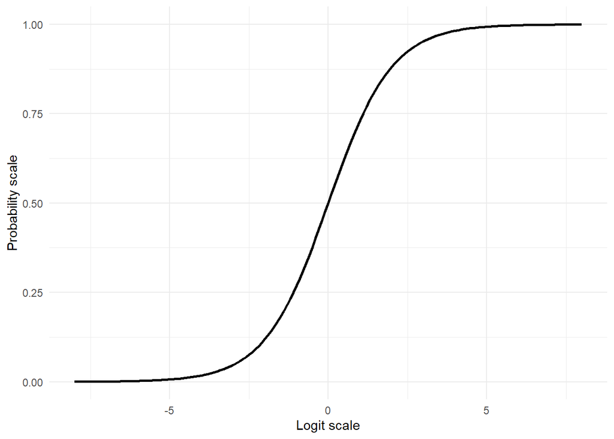

```r
tibble(x = seq(-8, 8, by = 0.1)) |>
    mutate(y = plogis(x)) |>
    ggplot(aes(x = x, y = y)) + geom_line(size = 1) + labs(x = "Logit scale", y = "Probability scale") +
    theme_minimal()
```

#### 7.1.2.3 Ploting priors

This visualises our priors, to aid in specification.

[figure not shown]

```r
# Generate data points
x <- seq(-20, 20, length.out = 1000)  # Adjusted range for better visualization

# Define parameters for the distributions
loc_logistic <- 0
scale_logistic <- 3

df_student_t <- 3
loc_student_t <- 0
scale_student_t <- 2.5

loc_normal <- 0
scale_normal <- 3

# Calculate PDFs
pdf_logistic <- dlogis(x, location = loc_logistic, scale = scale_logistic)
pdf_student_t <- dt(x, df = df_student_t)
pdf_normal <- dnorm(x, mean = loc_normal, sd = scale_normal)

# Plot the PDFs
df <- data.frame(x = x, Logistic = pdf_logistic, Student_t = pdf_student_t, Normal = pdf_normal)
ggplot(df, aes(x)) +
  geom_line(aes(y = Logistic, color = "Logistic(0, 3)")) + # Default priors of Logistic(0,1) have been broadened as these priors seemed too restrictive
  geom_line(aes(y = Student_t, color = "Student_t(3, 0, 2.5)")) +
  geom_line(aes(y = Normal, color = "Normal(0, 3)")) + #For the beta coefficient prior, we will set it to be normally distributed around 0 with an sd of 5, here is the plotted prior distribution
  labs(title = "Probability Density Functions",
       x = "x",
       y = "Probability Density") +
  scale_color_manual(name = "Distribution", values = c("Logistic(0, 3)" = "blue", "Student_t(3, 0, 2.5)" = "green", "Normal(0, 3)" = "red")) +
  theme_minimal()
```

#### 7.1.2.4 Setting priors

```r
priors <- c(set_prior("student_t(3, 0, 2.5)", class = "Intercept"), set_prior("logistic(0, 3)",
    class = "Intercept", dpar = "coi"), set_prior("logistic(0, 3)", class = "Intercept",
    dpar = "zoi"), set_prior("student_t(3, 0, 2.5)", class = "Intercept", dpar = "phi",
    lb = 0), set_prior("student_t(3, 0, 2.5)", class = "sd", lb = 0), set_prior("student_t(3, 0, 2.5)",
    class = "sd", dpar = "phi", lb = 0), set_prior("student_t(3, 0, 2.5)", class = "sd",
    dpar = "zoi", lb = 0), set_prior("student_t(3, 0, 2.5)", class = "sd", dpar = "coi",
    lb = 0), set_prior("normal(0, 3)", class = "b"), set_prior("normal(0, 3)", class = "b",
    dpar = "phi"), set_prior("normal(0, 3)", class = "b", dpar = "zoi"), set_prior("normal(0, 3)",
    class = "b", dpar = "coi"))
```

#### 7.1.2.5 Prior predictive check

Here we will build a prior only model, to check the specification was reasonable

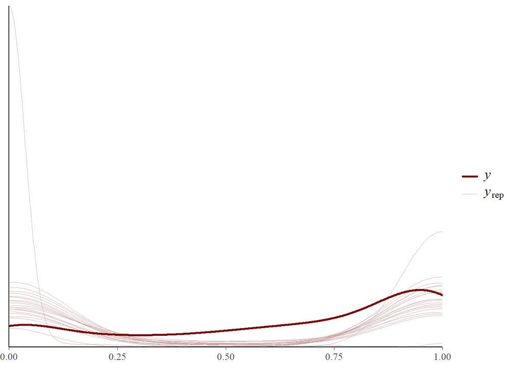

```r
prior_formula <- bf(
  # mu (mean) part
  goby_out ~ stroke*stage + goby_number + shrimp_number + shrimp_species + (1 | site/burrow),
  # phi (precision) part
  phi ~ stroke*stage + goby_number + shrimp_number + shrimp_species + (1 | site/burrow),
  # alpha (zero-one-inflation) part
  zoi ~ stroke*stage + goby_number + shrimp_number + shrimp_species + (1 | site/burrow),
  # The one-inflated part, conditional on the 0s
  coi ~ stroke*stage + goby_number + shrimp_number + shrimp_species + (1 | site/burrow),

  family = zero_one_inflated_beta()
)

prior_model <- brm(
  prior_formula,
  data = final_df,
  family = zero_one_inflated_beta(),
  prior = priors,
  control = list(adapt_delta = 0.99,
                 max_treedepth = 12),
  chains = 4, iter = 1000, warmup = 100,
  cores = 4, threads = threading(2),
  backend = "cmdstanr",
  seed = 1,
  sample_prior = "only",
  file = "prior_check"
)

color_scheme_set("red")
pp_check(prior_model, ndraws=20)
```

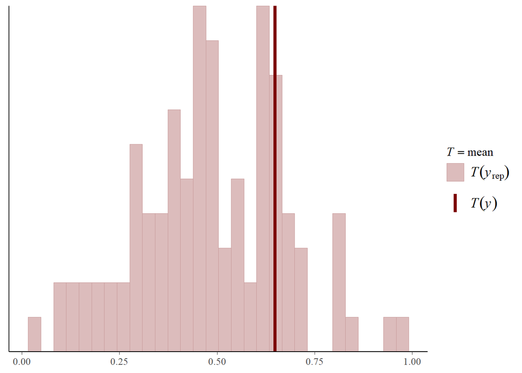

```r
pp_check(prior_model, ndraws=100, type = 'stat', stat = 'mean')
```

### 7.1.3 Final model structure

This is the structure of the final model

```r
goby_out_formula_1 <- bf(
  # mu (mean) part
  goby_out ~ stroke*stage + goby_number + shrimp_number + shrimp_species + (1 | site/burrow),
  # phi (precision) part
  phi ~ stroke*stage + goby_number + shrimp_number + shrimp_species + (1 | site/burrow),
  # alpha (zero-one-inflation) part
  zoi ~ stroke*stage + goby_number + shrimp_number + shrimp_species + (1 | site/burrow),
  # The one-inflated part, conditional on the 0s
  coi ~ stroke*stage + goby_number + shrimp_number + shrimp_species + (1 | site/burrow),

  family = zero_one_inflated_beta()
)
```

### 7.1.4 Running model

Now we run and save the model.

⏭️ **Skip this step** if you have downloaded the saved model ‘goby_out_model.rds’. You will load the model in the next step.

🚧 Jack, you might consider wiring the brms models to a folder called ‘4-mods’ 🚧

```r
# goby_out_model <- brm( goby_out_formula_1, data = final_df, family =
# zero_one_inflated_beta(), prior = priors, control = list(adapt_delta = 0.99,
# max_treedepth = 12), chains = 4, iter = 4000, warmup = 1000, cores = 4,
# threads = threading(2), backend = 'cmdstanr', seed = 1, file =
# 'goby_out_model' )
```

Here we reload the saved model.

```r
goby_out_model <- readRDS(file = "goby_out_model.rds")
```

Looking at the basic model summary

```r
summary(goby_out_model)
```

```
##  Family: zero_one_inflated_beta
##   Links: mu = logit; phi = log; zoi = logit; coi = logit
## Formula: goby_out ~ stroke * stage + goby_number + shrimp_number + shrimp_species + (1 | site/burrow)
##          phi ~ stroke * stage + goby_number + shrimp_number + shrimp_species + (1 | site/burrow)
##          zoi ~ stroke * stage + goby_number + shrimp_number + shrimp_species + (1 | site/burrow)
##          coi ~ stroke * stage + goby_number + shrimp_number + shrimp_species + (1 | site/burrow)
##    Data: final_df (Number of observations: 369)
##   Draws: 4 chains, each with iter = 4000; warmup = 1000; thin = 1;
##          total post-warmup draws = 12000
##
## Multilevel Hyperparameters:
## ~site (Number of levels: 5)
##                   Estimate Est.Error l-95% CI u-95% CI Rhat Bulk_ESS Tail_ESS
## sd(Intercept)         0.20      0.21     0.01     0.76 1.00     3055     5294
## sd(phi_Intercept)     0.28      0.26     0.01     0.96 1.00     2782     4846
## sd(zoi_Intercept)     0.84      0.60     0.06     2.39 1.00     2557     2582
## sd(coi_Intercept)     1.82      1.70     0.07     6.09 1.00     6696     6013
##
## ~site:burrow (Number of levels: 123)
##                   Estimate Est.Error l-95% CI u-95% CI Rhat Bulk_ESS Tail_ESS
## sd(Intercept)         0.95      0.12     0.72     1.21 1.00     2977     5088
## sd(phi_Intercept)     0.18      0.13     0.01     0.49 1.00     2547     4278
## sd(zoi_Intercept)     1.75      0.38     1.07     2.55 1.00     3256     5519
## sd(coi_Intercept)    14.94      8.83     5.25    37.23 1.00     4059     6542
##
## Regression Coefficients:
##                               Estimate Est.Error l-95% CI u-95% CI Rhat
## Intercept                        -0.56      0.58    -1.70     0.58 1.00
## phi_Intercept                     0.54      0.56    -0.60     1.61 1.00
## zoi_Intercept                    -4.65      1.52    -7.77    -1.80 1.00
## coi_Intercept                     3.63      4.52    -4.69    13.29 1.00
## stroke4                          -0.43      0.34    -1.09     0.23 1.00
## strokecontrol                     0.25      0.33    -0.41     0.90 1.00
## stagePost                        -0.04      0.23    -0.49     0.40 1.00
## stagePre                          0.31      0.23    -0.14     0.76 1.00
## goby_number2                      0.76      0.27     0.23     1.29 1.00
## shrimp_number2                    0.69      0.28     0.14     1.25 1.00
## shrimp_number3                    0.38      0.84    -1.30     2.05 1.00
## shrimp_speciesmannarensis         0.41      0.50    -0.58     1.37 1.00
## shrimp_speciessciolii             0.31      0.69    -1.06     1.68 1.00
```

[output cut: 97 more lines]

```
## coi_stagePre                      9290     8901
## coi_goby_number2                  9040     8784
## coi_shrimp_number2                8762     8986
## coi_shrimp_number3               13937     8873
## coi_shrimp_speciesmannarensis    11322     9704
## coi_shrimp_speciessciolii        14206     9008
## coi_shrimp_speciesunknown        10515     9219
## coi_stroke4:stagePost            11886     9584
## coi_strokecontrol:stagePost      11208     9021
## coi_stroke4:stagePre             12132     8898
## coi_strokecontrol:stagePre       12755     8356
##
## Draws were sampled using sample(hmc). For each parameter, Bulk_ESS
## and Tail_ESS are effective sample size measures, and Rhat is the potential
## scale reduction factor on split chains (at convergence, Rhat = 1).
```

### 7.1.5 Model fit and diagnostics

#### 7.1.5.1 Model convergence

Here we check the model convergence using R-hat

```r
# convergence diagnostics (R-hat)
extract_rhats <- function(model) {
    model_summary <- summary(model)
    # extract R-hat values for fixed effects
    fixed_rhats <- model_summary$fixed[, "Rhat", drop = FALSE]
    # check for random effects and extract R-hat values if present
    if (!is.null(model_summary$random)) {
        random_rhats <- do.call(rbind, lapply(model_summary$random, function(x) x[,
            "Rhat", drop = FALSE]))
        # combine fixed and random effects R-hat values
        rhats <- rbind(fixed_rhats, random_rhats)
    } else {
        rhats <- fixed_rhats
    }

    return(rhats)
}

extract_rhats(goby_out_model)
```

```
##                                    Rhat
## Intercept                     1.0005578
## phi_Intercept                 1.0009595
## zoi_Intercept                 0.9999930
## coi_Intercept                 1.0002505
## stroke4                       1.0002134
## strokecontrol                 1.0000376
## stagePost                     1.0007459
## stagePre                      1.0012678
## goby_number2                  1.0002532
## shrimp_number2                1.0010880
## shrimp_number3                1.0006650
## shrimp_speciesmannarensis     1.0013751
## shrimp_speciessciolii         1.0010367
## shrimp_speciesunknown         1.0011741
## stroke4:stagePost             1.0006817
## strokecontrol:stagePost       1.0003990
## stroke4:stagePre              1.0006277
## strokecontrol:stagePre        1.0008589
## phi_stroke4                   1.0005548
## phi_strokecontrol             1.0000521
## phi_stagePost                 1.0003700
## phi_stagePre                  1.0011527
## phi_goby_number2              1.0005467
## phi_shrimp_number2            1.0001211
## phi_shrimp_number3            0.9999848
## phi_shrimp_speciesmannarensis 1.0010171
## phi_shrimp_speciessciolii     1.0007876
## phi_shrimp_speciesunknown     1.0005111
## phi_stroke4:stagePost         1.0005792
## phi_strokecontrol:stagePost   0.9999932
## phi_stroke4:stagePre          1.0002913
## phi_strokecontrol:stagePre    1.0001436
## zoi_stroke4                   1.0003714
## zoi_strokecontrol             1.0010740
## zoi_stagePost                 1.0000282
## zoi_stagePre                  1.0004724
## zoi_goby_number2              1.0006268
## zoi_shrimp_number2            1.0000590
## zoi_shrimp_number3            1.0000891
```

[output cut: 14 more lines]

```
## coi_shrimp_speciesmannarensis 1.0001202
## coi_shrimp_speciessciolii     0.9999673
## coi_shrimp_speciesunknown     1.0002196
## coi_stroke4:stagePost         1.0000630
## coi_strokecontrol:stagePost   1.0000740
## coi_stroke4:stagePre          1.0005086
## coi_strokecontrol:stagePre    1.0002274
## site.sd(Intercept)            1.0011060
## site.sd(phi_Intercept)        1.0006338
## site.sd(zoi_Intercept)        1.0006809
## site.sd(coi_Intercept)        1.0006903
## site:burrow.sd(Intercept)     1.0000363
## site:burrow.sd(phi_Intercept) 1.0007214
## site:burrow.sd(zoi_Intercept) 1.0010080
## site:burrow.sd(coi_Intercept) 1.0009396
```

#### 7.1.5.2 Model fit

Now we will asses model fit.

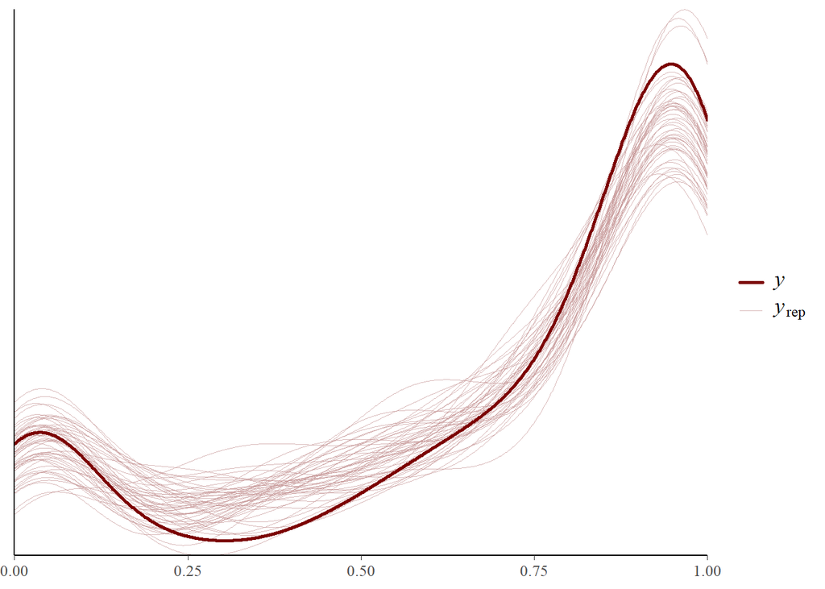

```r
# posterior predictive checks
pp_check(goby_out_model, ndraws = 50)
```

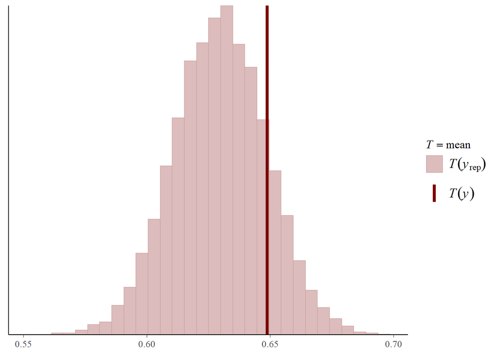

```r
pp_check(goby_out_model, type = "stat", stat = "mean")
```

Creating a summary of the observed data

```r
summary(fitted(goby_out_model))
```

```
##     Estimate        Est.Error            Q2.5              Q97.5
##  Min.   :0.1588   Min.   :0.04909   Min.   :0.007135   Min.   :0.4130
##  1st Qu.:0.4984   1st Qu.:0.10560   1st Qu.:0.213903   1st Qu.:0.7719
##  Median :0.6774   Median :0.12828   Median :0.379441   Median :0.8931
##  Mean   :0.6297   Mean   :0.12544   Mean   :0.367441   Mean   :0.8473
##  3rd Qu.:0.7918   3rd Qu.:0.14591   3rd Qu.:0.516355   3rd Qu.:0.9451
##  Max.   :0.9326   Max.   :0.24505   Max.   :0.803405   Max.   :0.9987
```

To compare with a summary of the predicted data, they seem to align very nicely.

```r
summary(predict(goby_out_model))
```

```
##     Estimate        Est.Error           Q2.5             Q97.5
##  Min.   :0.1617   Min.   :0.1256   Min.   :0.00000   Min.   :0.9373
##  1st Qu.:0.4965   1st Qu.:0.2477   1st Qu.:0.00000   1st Qu.:1.0000
##  Median :0.6758   Median :0.2967   Median :0.00000   Median :1.0000
##  Mean   :0.6300   Mean   :0.2852   Mean   :0.06545   Mean   :0.9991
##  3rd Qu.:0.7931   3rd Qu.:0.3292   3rd Qu.:0.04122   3rd Qu.:1.0000
##  Max.   :0.9351   Max.   :0.4560   Max.   :0.60407   Max.   :1.0000
```

🚧 Interesting that a 16% of the observations are not being predicted very well by the model, do we think this is an issue 🚧

Using leave one out (loo) measure of fit, the model appears to preform ok, 16% Pareto k estimates falls outside the good range (0.7, 1]

```r
loo(goby_out_model)
```

```
##
## Computed from 12000 by 369 log-likelihood matrix.
##
##          Estimate   SE
## elpd_loo   -122.7 20.2
## p_loo       174.7  8.1
## looic       245.4 40.4
## ------
## MCSE of elpd_loo is NA.
## MCSE and ESS estimates assume MCMC draws (r_eff in [0.4, 1.5]).
##
## Pareto k diagnostic values:
##                          Count Pct.    Min. ESS
## (-Inf, 0.7]   (good)     310   84.0%   530
##    (0.7, 1]   (bad)       57   15.4%   <NA>
##    (1, Inf)   (very bad)   2    0.5%   <NA>
## See help('pareto-k-diagnostic') for details.
```

### 7.1.6 Posterior marginal effects

#### 7.1.6.1 Pairwise contrasts of stroke and stage

```r
goby_out_contrast_effect <- goby_out_model |>
    emmeans(~stroke * stage, epred = TRUE, re_formla = NULL, rg.limit = 14000) |>
    contrast(method = "revpairwise")

# Extract the relevant contrast information
goby_out_results.table <- as.data.frame(goby_out_contrast_effect) |>
    dplyr::filter(contrast %in% c("control Pre - 2 Pre", "control Pre - 4 Pre", "4 Pre - 2 Pre",
        "control Pre - control During", "control Pre - control Post", "4 Pre - 4 During",
        "4 Pre - 4 Post", "2 Pre - 2 During", "2 Pre - 2 Post"))

goby_out_results.table %>%
    gt()
```

| contrast | estimate | lower.HPD | upper.HPD |
| --- | --- | --- | --- |
| 2 Pre - 2 During | 0.061315258 | -0.04085772 | 0.16578566 |
| 2 Pre - 2 Post | 0.066975840 | -0.04508346 | 0.18552813 |
| 4 Pre - 4 During | 0.151843511 | 0.01311128 | 0.28627348 |
| 4 Pre - 4 Post | 0.066749103 | -0.08135213 | 0.22150063 |
| 4 Pre - 2 Pre | 0.004577346 | -0.15864033 | 0.13777826 |
| control Pre - control During | -0.069481503 | -0.20576921 | 0.06260540 |
| control Pre - control Post | -0.091802951 | -0.25366372 | 0.05686286 |
| control Pre - 2 Pre | -0.067301600 | -0.22705272 | 0.08824646 |
| control Pre - 4 Pre | -0.071299138 | -0.25472546 | 0.10683535 |

Pull predicted contrast for a plot

```r
goby_out_contrast_draws <- goby_out_model |>
    emmeans(~stroke * stage, epred = TRUE, re_formla = NULL, rg.limit = 14000) |>
    contrast(method = "revpairwise") |>
    gather_emmeans_draws()

goby_out_temporal_contrasts <- goby_out_contrast_draws |>
    dplyr::filter(contrast %in% c("control Pre - control During", "control Pre - control Post",
        "4 Pre - 4 During", "4 Pre - 4 Post", "2 Pre - 2 During", "2 Pre - 2 Post")) |>
    mutate(stroke = ifelse(contrast %in% c("control Pre - control During", "control Pre - control Post"),
        "Control", ifelse(contrast %in% c("4 Pre - 4 During", "4 Pre - 4 Post"),
            "4", "2")))

goby_out_temporal_contrasts$stroke <- factor(goby_out_temporal_contrasts$stroke,
    levels = c("Control", "4", "2"))
```

Making a figure

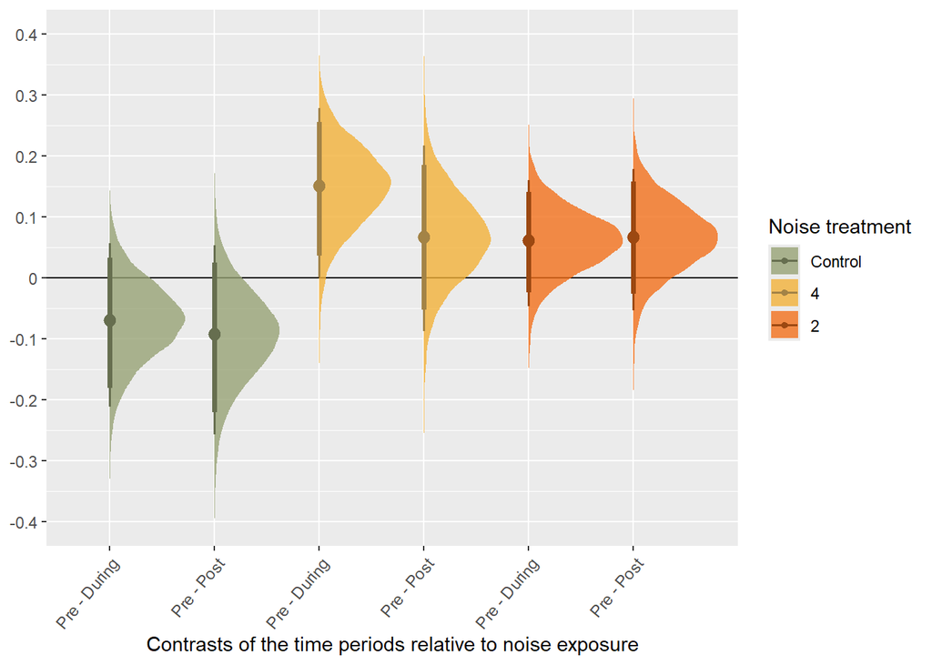

```r
fig.goby_out_temporal_contrasts <- ggplot(goby_out_temporal_contrasts, aes(x = .value,
    y = factor(contrast, levels = c("control Pre - control During", "control Pre - control Post",
        "4 Pre - 4 During", "4 Pre - 4 Post", "2 Pre - 2 During", "2 Pre - 2 Post")),
    color = stroke, fill = stroke)) + geom_vline(xintercept = 0, color = "black",
    size = 0.5) + stat_halfeye(.width = c(0.89, 0.95)) + scale_color_manual(values = c(colour11,
    colour12, colour13)) + scale_fill_manual(values = alpha(c(colour1, colour2, colour3),
    0.8)) + labs(y = "Contrasts of the time periods relative to noise exposure",
    fill = "Noise treatment", color = "Noise treatment", fill_ramp = "Credible interval") +
    xlab(NULL) + coord_flip() + theme(legend.position = "right", axis.text.x = element_text(angle = 50,
    hjust = 1)) + scale_y_discrete(labels = c("Pre - During", "Pre - Post", "Pre - During",
    "Pre - Post", "Pre - During", "Pre - Post")) + scale_x_continuous(breaks = seq(-0.4,
    0.5, 0.1), labels = c("-0.4", "-0.3", "-0.2", "-0.1", "0", "0.1", "0.2", "0.3",
    "0.4", "0.5"), limits = c(-0.4, 0.4))

fig.goby_out_temporal_contrasts
```

### Extracting and plotting model estimates

#### 7.1.6.2 Extracting estimates

```r
goby_out_model_estimates <- goby_out_model |>
    emmeans(~stroke * stage, epred = TRUE, rg.limit = 14000, re_formula = NA)

goby_out_model_estimates <- as.data.frame(goby_out_model_estimates)

# Storing the model estimate means for each group to plot later on
goby_out_model_estimates_control <- goby_out_model_estimates |>
    dplyr::filter(stroke == "control") |>
    rename(.value = emmean)

goby_out_model_estimates_four <- goby_out_model_estimates |>
    dplyr::filter(stroke == "4") |>
    rename(.value = emmean)

goby_out_model_estimates_two <- goby_out_model_estimates |>
    dplyr::filter(stroke == "2") |>
    rename(.value = emmean)
```

#### 7.1.6.3 Plotting model estimates and raw data

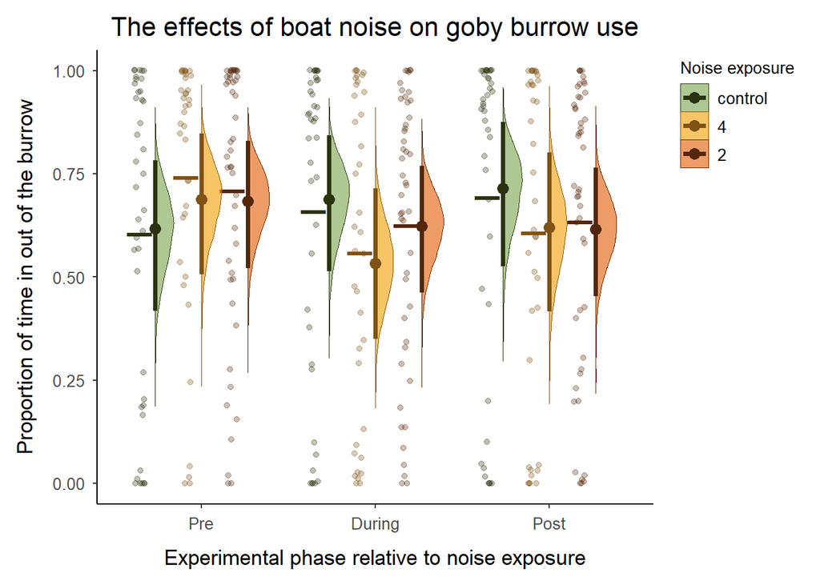

```r
goby_out_model_draws <- goby_out_model |>
    emmeans(~stroke * stage, epred = TRUE, rg.limit = 14000, re_formula = NA) |>
    gather_emmeans_draws()

goby_out_model_draws <- goby_out_model_draws |>
    rename(emmean = .value)

goby_out_raw_data <- final_df |>
    rename(emmean = goby_out)

goby_out_raw_data$stage <- factor(goby_out_raw_data$stage, levels = c("Pre", "During",
    "Post"))
goby_out_raw_data$stroke <- factor(goby_out_raw_data$stroke, levels = c("control",
    "4", "2"))

goby_out_model_estimates$stage <- factor(goby_out_model_estimates$stage, levels = c("Pre",
    "During", "Post"))
goby_out_model_estimates$stroke <- factor(goby_out_model_estimates$stroke, levels = c("control",
    "4", "2"))

goby_out_model_draws$stage <- factor(goby_out_model_draws$stage, levels = c("Pre",
    "During", "Post"))
goby_out_model_draws$stroke <- factor(goby_out_model_draws$stroke, levels = c("control",
    "4", "2"))

goby_out_means <- goby_out_raw_data |>
    group_by(stage, stroke) |>
    summarise(emmean = mean(emmean))


goby_out_fig_together <- ggplot(data = goby_out_raw_data, aes(x = stage, y = emmean,
    color = stroke, fill = stroke)) + geom_point(data = goby_out_means, alpha = 1,
    position = position_dodgenudge(width = 0.8, x = -0.09), size = 9, shape = "_") +
    geom_half_point(alpha = 0.3, position = position_dodgenudge(width = 0.8, x = -0.03),
        side = "l", range_scale = 0.5) + geom_half_violin(data = goby_out_model_draws,
    aes(x = stage, y = emmean, color = stroke, fill = stroke), alpha = 0.6, position = position_dodge(width = 0.8),
    side = "r", size = 0) + geom_point(data = goby_out_model_estimates, aes(x = stage,
    y = emmean, color = stroke), position = position_dodge(width = 0.8), size = 3) +
    geom_errorbar(data = goby_out_model_estimates, aes(x = stage, y = emmean, ymin = lower.HPD,
        ymax = upper.HPD, color = stroke), position = position_dodge(width = 0.8),
        width = 0, size = 1.25) + scale_fill_manual(values = c(control = "#76A34A",
    `4` = "#F29E00", `2` = "#E25A00"), name = "Noise exposure", guide = guide_legend(override.aes = list(size = 3))) +
    scale_color_manual(values = c(control = "#2A330E", `4` = "#805213", `2` = "#542709"),
        name = "Noise exposure", guide = guide_legend(override.aes = list(size = 3))) +
    scale_x_discrete(labels = c("Pre", "During", "Post")) + labs(title = "The effects of boat noise on goby burrow use",
    y = "Proportion of time in out of the burrow", x = "Experimental phase relative to noise exposure") +
    theme_classic() + theme(axis.text.x = element_text(size = 10, margin = margin(t = 5)),
    axis.text.y = element_text(size = 10, margin = margin(r = 5)), axis.title.x = element_text(size = 13,
        margin = margin(t = 10)), axis.title.y = element_text(size = 13, margin = margin(r = 10)),
    legend.text = element_text(size = 10), legend.title = element_text(size = 10),
    legend.position = "right", legend.justification = "top", plot.title = element_text(hjust = 0.5,
        size = 16), plot.margin = margin(10, 10, 10, 10))

goby_out_fig_together
```

#### 7.1.6.4 Plotting control estimates and raw data

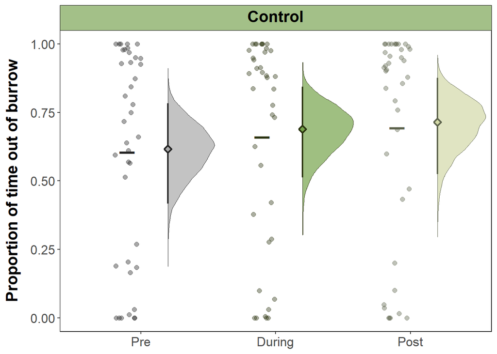

```r
goby_out_model_draws <- goby_out_model |>
    emmeans(~stroke * stage, epred = TRUE, rg.limit = 14000, re_formula = NA) |>
    gather_emmeans_draws()

goby_out_raw_data <- final_df |>
    rename(.value = goby_out)

goby_out_model_draws$stage <- factor(goby_out_model_draws$stage, levels = c("Pre",
    "During", "Post"))
goby_out_model_draws$stroke <- factor(goby_out_model_draws$stroke, levels = c("control",
    "4", "2"))

goby_out_control_model_draws <- goby_out_model_draws |>
    dplyr::filter(stroke == "control")

goby_control_raw_data <- final_df |>
    dplyr::filter(stroke == "control") |>
    rename(.value = goby_out)

goby_control_means <- goby_control_raw_data |>
    group_by(stage) |>
    summarise(.value = mean(.value))

goby_control_raw_data$stage <- factor(goby_control_raw_data$stage, levels = c("Pre",
    "During", "Post"))

# assigning a value for the baseline mean
goby_out_model_estimates_control_intercept <- goby_out_model_estimates_control %>%
    dplyr::filter(stage == "Pre") %>%
    pull(.value)

goby_out_fig_control <- ggplot(goby_control_raw_data, aes(y = .value, x = stage,
    fill = stage, color = stage)) + geom_half_violin(data = goby_out_control_model_draws,
    alpha = 0.7, size = 0, side = "r", position = position_nudge(x = 0.2)) + geom_jitter(position = position_jitternudge(x = -0.1,
    width = 0.1, nudge.from = "jittered"), alpha = 0.4, size = 2) + geom_crossbar(alpha = 0.6,
    size = 0.8, data = goby_out_model_estimates_control, aes(ymin = lower.HPD, ymax = upper.HPD),
    width = 0, position = position_nudge(x = 0.2)) + geom_point(pch = 23, stroke = 1.2,
    data = goby_out_model_estimates_control, size = 2, position = position_nudge(x = 0.2)) +
    geom_point(data = goby_control_means, position = position_dodgenudge(width = 0.8,
        x = -0.1), size = 9, shape = "_") + labs(x = "Period relative to treatment",
    y = "Proportion of time out of burrow") + theme(legend.position = "none", axis.title.x = element_blank(),
    axis.text.x = element_text(size = 13), axis.text.y = element_text(size = 13),
    panel.grid = element_blank(), axis.title.y = element_text(size = 16, face = "bold",
        margin = margin(t = 0, b = 0, l = 0, r = 10)), plot.title = element_textbox_simple(face = "bold",
        size = 16, halign = 0.5, linewidth = 0.3, linetype = 1, color = "black",
        fill = "#A3C088", padding = margin(5, 5, 5, 5)), panel.background = element_rect(fill = "white",
        colour = "black"), plot.background = element_rect(fill = NA, colour = NA)) +
    ggtitle("Control") + scale_fill_manual(values = c(Pre = "darkgrey", During = "#76A34A",
    Post = "#D3D9A7")) + scale_color_manual(values = c(Pre = "#242424", During = "#2A330E",
    Post = "#5d634c"))

goby_out_fig_control
```

#### Plotting 4-stroke estimates and raw data

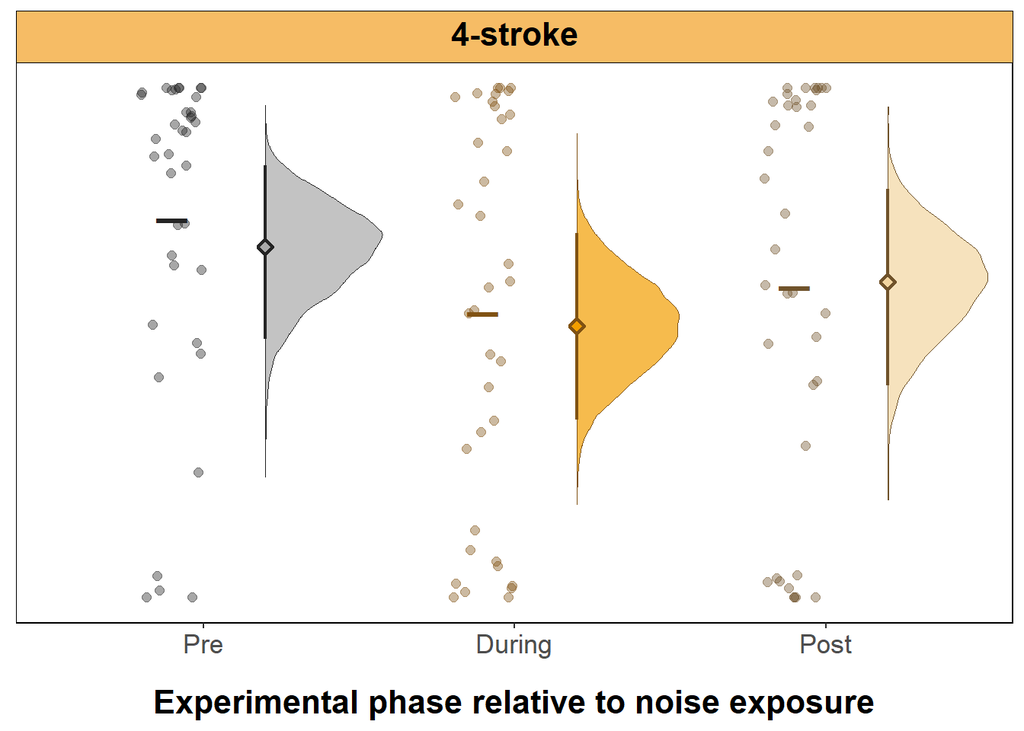

```r
goby_out_control_model_draws <- goby_out_model_draws |>
    dplyr::filter(stroke == "4")

goby_four_raw_data <- final_df |>
    dplyr::filter(stroke == "4") |>
    rename(.value = goby_out)

goby_four_raw_data$stage <- factor(goby_four_raw_data$stage, levels = c("Pre", "During",
    "Post"))

goby_four_means <- goby_four_raw_data |>
    group_by(stage) |>
    summarise(.value = mean(.value))

goby_out_fig_four <- ggplot(goby_four_raw_data, aes(y = .value, x = stage, fill = stage,
    color = stage)) + geom_half_violin(data = goby_out_control_model_draws, alpha = 0.7,
    size = 0, side = "r", position = position_nudge(x = 0.2)) + geom_jitter(position = position_jitternudge(x = -0.1,
    width = 0.1, nudge.from = "jittered"), alpha = 0.4, size = 2) + geom_crossbar(alpha = 0.6,
    size = 0.8, data = goby_out_model_estimates_four, aes(ymin = lower.HPD, ymax = upper.HPD),
    width = 0, position = position_nudge(x = 0.2)) + geom_point(pch = 23, stroke = 1.2,
    data = goby_out_model_estimates_four, size = 2, position = position_nudge(x = 0.2)) +
    geom_point(data = goby_four_means, position = position_dodgenudge(width = 0.8,
        x = -0.1), size = 9, shape = "_") + xlab("Experimental phase relative to noise exposure") +
    theme(legend.position = "none", axis.title.y = element_blank(), axis.text.x = element_text(size = 13),
        axis.text.y = element_blank(), axis.ticks.y = element_blank(), panel.grid = element_blank(),
        axis.title.x = element_text(size = 16, face = "bold", margin = margin(t = 15,
            b = 0, l = 0, r = 0)), plot.title = element_textbox_simple(face = "bold",
            size = 16, halign = 0.5, linewidth = 0.3, linetype = 1, color = "black",
            fill = "#F6BC65", padding = margin(5, 5, 5, 5)), panel.background = element_rect(fill = "white",
            colour = "black"), plot.background = element_rect(fill = NA, colour = NA)) +
    ggtitle("4-stroke") + scale_fill_manual(values = c(Pre = "darkgrey", During = "#F29E00",
    Post = "#F2D5A0")) + scale_color_manual(values = c(Pre = "#242424", During = "#805213",
    Post = "#70532b"))

goby_out_fig_four
```

#### 7.1.6.5 Plotting 2-stroke estimates and raw data

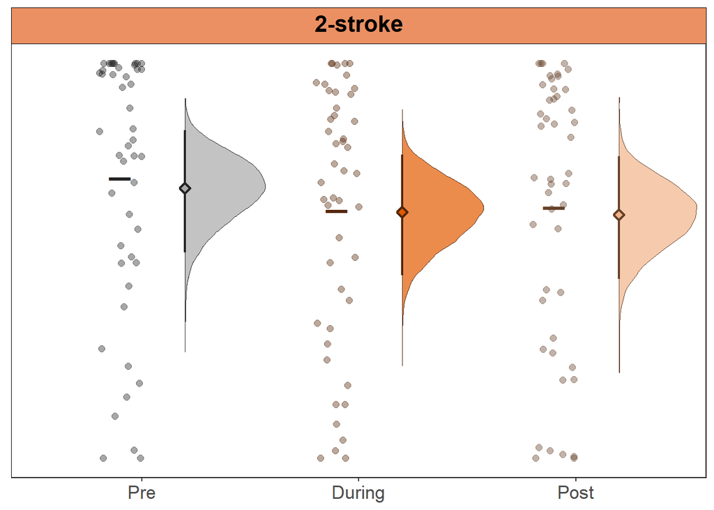

```r
goby_out_control_model_draws <- goby_out_model_draws |>
    dplyr::filter(stroke == "2")

goby_two_raw_data <- final_df |>
    dplyr::filter(stroke == "2") |>
    rename(.value = goby_out)

goby_two_raw_data$stage <- factor(goby_two_raw_data$stage, levels = c("Pre", "During",
    "Post"))

goby_two_means <- goby_two_raw_data |>
    group_by(stage) |>
    summarise(.value = mean(.value))

goby_out_fig_two <- ggplot(goby_two_raw_data, aes(y = .value, x = stage, fill = stage,
    color = stage)) + geom_half_violin(data = goby_out_control_model_draws, alpha = 0.7,
    size = 0, side = "r", position = position_nudge(x = 0.2)) + geom_jitter(position = position_jitternudge(x = -0.1,
    width = 0.1, nudge.from = "jittered"), alpha = 0.4, size = 2) + geom_crossbar(alpha = 0.6,
    size = 0.8, data = goby_out_model_estimates_two, aes(ymin = lower.HPD, ymax = upper.HPD),
    width = 0, position = position_nudge(x = 0.2)) + geom_point(pch = 23, stroke = 1.2,
    data = goby_out_model_estimates_two, size = 2, position = position_nudge(x = 0.2)) +
    geom_point(data = goby_two_means, position = position_dodgenudge(width = 0.8,
        x = -0.1), size = 9, shape = "_") + theme(legend.position = "none", axis.title.x = element_blank(),
    axis.text.x = element_text(size = 13), axis.title.y = element_blank(), axis.text.y = element_blank(),
    axis.ticks.y = element_blank(), panel.grid = element_blank(), plot.title = element_textbox_simple(face = "bold",
        size = 16, halign = 0.5, linewidth = 0.3, linetype = 1, color = "black",
        fill = "#EB9063", padding = margin(5, 5, 5, 5)), panel.background = element_rect(fill = "white",
        colour = "black"), plot.background = element_rect(fill = NA, colour = NA)) +
    ggtitle("2-stroke") + scale_fill_manual(values = c(Pre = "darkgrey", During = "#E25A00",
    Post = "#F2B389")) + scale_color_manual(values = c(Pre = "#242424", During = "#542709",
    Post = "#66422a"))

goby_out_fig_two
```

#### 7.1.6.6 Combining plots into one figure

```r
goby_out_plot3 <- goby_out_fig_control + goby_out_fig_four + goby_out_fig_two + plot_layout(ncol = 3)
```

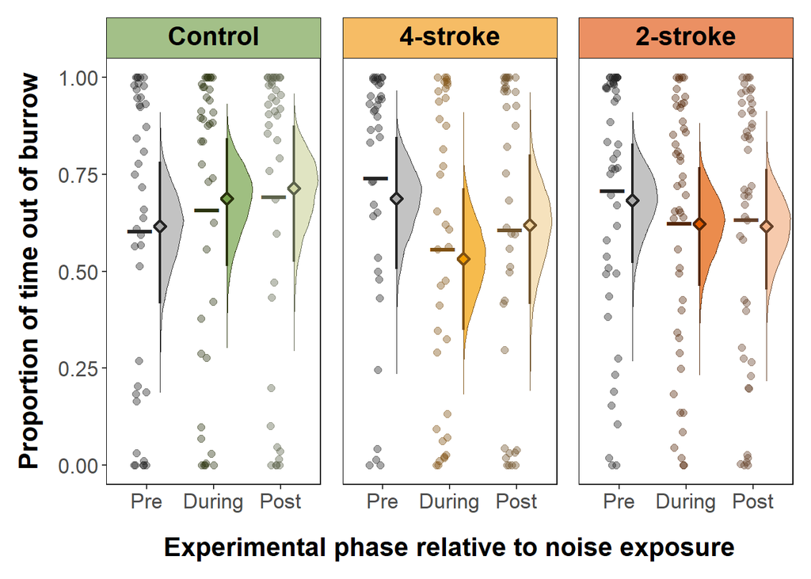

```r
goby_out_plot3
```

```r
ggsave("./3-figs/goby_out_plot3.jpeg", plot = goby_out_plot3, units = "px", width = 2200,
    height = 1400, dpi = 300)
ggsave("./3-figs/goby_out_plot3.pdf", plot = goby_out_plot3, units = "px", width = 2200,
    height = 1400)
```

### 7.1.7 Effects of covariates on the proportion of time gobies spent outside of the burrow

#### 7.1.7.1 Goby number

Estimates based on the number of gobies

```r
goby_out_model |>
    emmeans(~goby_number, epred = TRUE, re_formla = NULL)
```

```
##  goby_number emmean lower.HPD upper.HPD
##  1            0.575     0.423     0.729
##  2            0.707     0.549     0.842
##
## Results are averaged over the levels of: stroke, stage, shrimp_number, shrimp_species
## Point estimate displayed: median
## HPD interval probability: 0.95
```

```r
goby_out_goby_number <- goby_out_model |>
    emmeans(~goby_number, epred = TRUE, re_formla = NULL) |>
    contrast(method = "revpairwise")

goby_out_goby_number
```

```
##  contrast                    estimate lower.HPD upper.HPD
##  goby_number2 - goby_number1    0.128  -0.00135     0.249
##
## Results are averaged over the levels of: stroke, stage, shrimp_number, shrimp_species
## Point estimate displayed: median
## HPD interval probability: 0.95
```

Plotting contrast

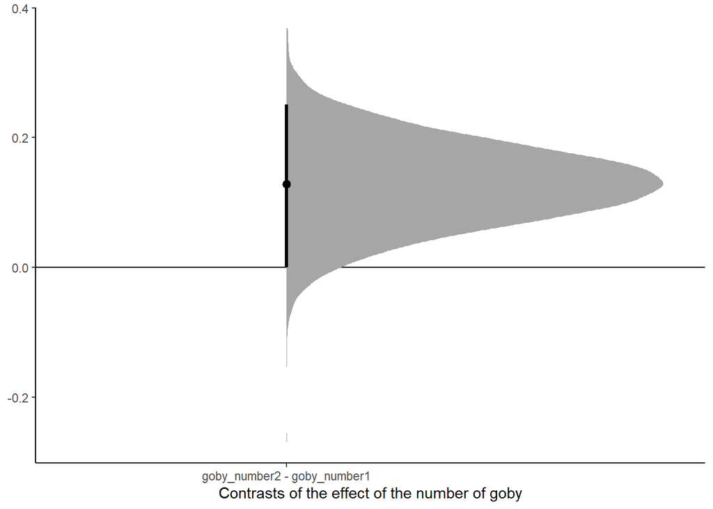

```r
goby_out_goby_number_draws <- goby_out_model |>
    emmeans(~goby_number, epred = TRUE, re_formla = NULL) |>
    contrast(method = "revpairwise") |>
    gather_emmeans_draws()

goby_out_goby_number_fig <- ggplot(goby_out_goby_number_draws, aes(x = .value, y = contrast)) +
    geom_vline(xintercept = 0, color = "black", size = 0.5) + stat_halfeye(.width = c(0.95)) +
    labs(y = "Contrasts of the effect of the number of goby", fill = "Noise treatment",
        color = "Noise treatment", fill_ramp = "Credible interval") + xlab(NULL) +
    theme_classic() + coord_flip()

goby_out_goby_number_fig
```

#### 7.1.7.2 Shrimp number

Estimates based on the number of shrimp

```r
goby_out_shrimp_number <- goby_out_model |>
    emmeans(~shrimp_number, epred = TRUE, re_formla = NULL) |>
    contrast(method = "revpairwise")

goby_out_shrimp_number
```

```
##  contrast                        estimate lower.HPD upper.HPD
##  shrimp_number2 - shrimp_number1   0.1431     0.025     0.269
##  shrimp_number3 - shrimp_number1   0.0867    -0.218     0.355
##  shrimp_number3 - shrimp_number2  -0.0574    -0.366     0.187
##
## Results are averaged over the levels of: stroke, stage, goby_number, shrimp_species
## Point estimate displayed: median
## HPD interval probability: 0.95
```

```r
goby_out_shrimp_number_estimates <- goby_out_model |>
    emmeans(~shrimp_number, epred = TRUE, re_formla = NULL)

goby_out_shrimp_number_estimates
```

```
##  shrimp_number emmean lower.HPD upper.HPD
##  1              0.566     0.413     0.708
##  2              0.711     0.614     0.803
##  3              0.651     0.339     0.909
##
## Results are averaged over the levels of: stroke, stage, goby_number, shrimp_species
## Point estimate displayed: median
## HPD interval probability: 0.95
```

Plotting contrast

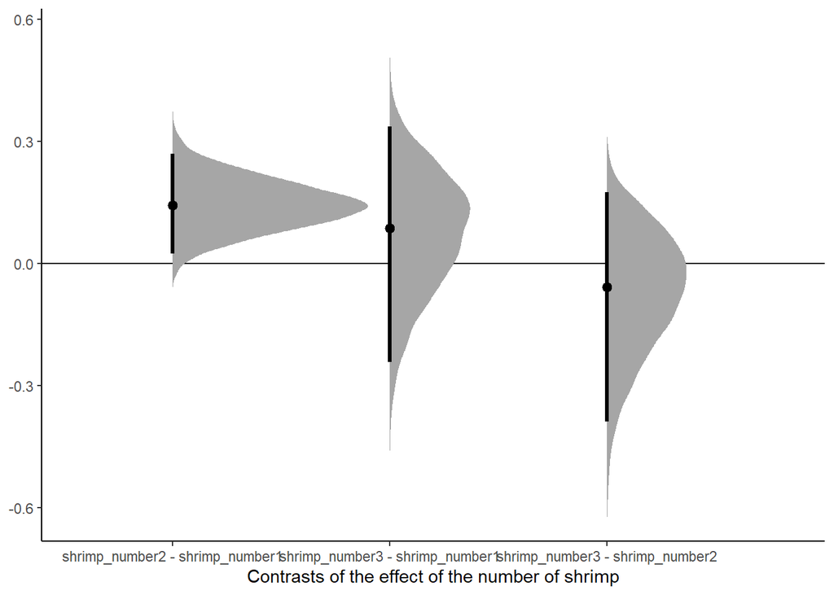

```r
goby_out_shrimp_number_draws <- goby_out_model |>
    emmeans(~shrimp_number, epred = TRUE, re_formla = NULL) |>
    contrast(method = "revpairwise") |>
    gather_emmeans_draws()

goby_out_shrimp_number_fig <- ggplot(goby_out_shrimp_number_draws, aes(x = .value,
    y = contrast)) + geom_vline(xintercept = 0, color = "black", size = 0.5) + stat_halfeye(.width = c(0.95)) +
    labs(y = "Contrasts of the effect of the number of shrimp", fill = "Noise treatment",
        color = "Noise treatment", fill_ramp = "Credible interval") + xlab(NULL) +
    theme_classic() + coord_flip()

goby_out_shrimp_number_fig
```

#### 7.1.7.3 Shrimp species

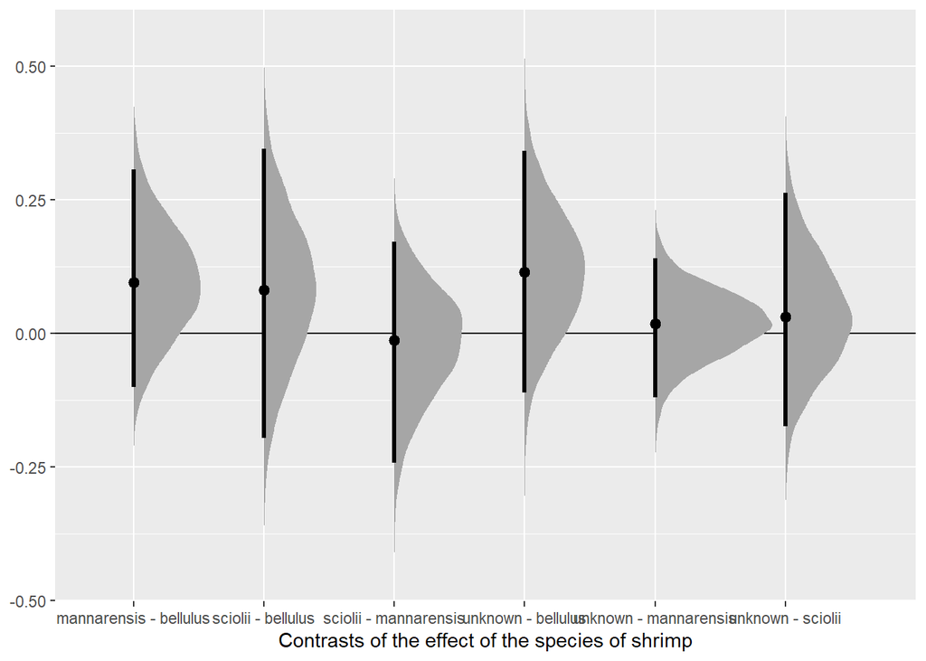

```r
goby_out_shrimp_species <- goby_out_model |>
    emmeans(~shrimp_species, epred = TRUE, re_formla = NULL) |>
    contrast(method = "revpairwise")

goby_out_shrimp_species <- as.data.frame(goby_out_shrimp_species)

goby_out_shrimp_species_estimates <- goby_out_model |>
    emmeans(~shrimp_species, epred = TRUE, re_formla = NULL)

goby_out_shrimp_species_estimates <- as.data.frame(goby_out_shrimp_species_estimates)

goby_out_shrimp_species_draws <- goby_out_model |>
    emmeans(~shrimp_species, epred = TRUE, re_formla = NULL) |>
    contrast(method = "revpairwise") |>
    gather_emmeans_draws()

goby_out_shrimp_species_fig <- ggplot(goby_out_shrimp_species_draws, aes(x = .value,
    y = contrast)) + geom_vline(xintercept = 0, color = "black", size = 0.5) + stat_halfeye(.width = c(0.95)) +
    labs(y = "Contrasts of the effect of the species of shrimp", fill = "Noise treatment",
        color = "Noise treatment", fill_ramp = "Credible interval") + xlab(NULL) +
    coord_flip()

goby_out_shrimp_species_fig
```

## 7.2 🦐 Shrimp time outside of burrow

Model structure

```r
shrimp_out_formula <- bf(
  # mu (mean) part
  shrimp_out ~ stroke*stage + shrimp_number + goby_number + shrimp_species + (1|site/burrow),
  # phi (precision) part
  phi ~ stroke*stage + shrimp_number + goby_number + shrimp_species + (1|site/burrow),
  # alpha (zero-one-inflation) part
  zoi ~ stroke*stage + shrimp_number + goby_number + shrimp_species + (1|site/burrow),
  # The one-inflated part, conditional on the 0s
  coi ~ stroke*stage + shrimp_number + goby_number + shrimp_species + (1|site/burrow),

  family = zero_one_inflated_beta()
)
```

Now we run and save the model.

⏭️ **Skip this step** if you have downloaded the saved model ‘shrimp_out_model.rds’. You will load the model in the next step

```r
# shrimp_out_model <- brm( shrimp_out_formula, data = final_df, family =
# zero_one_inflated_beta(), prior = priors, control = list(adapt_delta = 0.99,
# max_treedepth = 12), chains = 4, iter = 4000, warmup = 1000, cores = 4,
# threads = threading(2), backend = 'cmdstanr', seed = 1, file =
# 'shrimp_out_model' )
```

Here we reload the model.

```r
shrimp_out_model <- readRDS(file = "shrimp_out_model.rds")
```

```r
summary(shrimp_out_model)
```

```
##  Family: zero_one_inflated_beta
##   Links: mu = logit; phi = log; zoi = logit; coi = logit
## Formula: shrimp_out ~ stroke * stage + shrimp_number + goby_number + shrimp_species + (1 | site/burrow)
##          phi ~ stroke * stage + shrimp_number + goby_number + shrimp_species + (1 | site/burrow)
##          zoi ~ stroke * stage + shrimp_number + goby_number + shrimp_species + (1 | site/burrow)
##          coi ~ stroke * stage + shrimp_number + goby_number + shrimp_species + (1 | site/burrow)
##    Data: final_df (Number of observations: 369)
##   Draws: 4 chains, each with iter = 4000; warmup = 1000; thin = 1;
##          total post-warmup draws = 12000
##
## Multilevel Hyperparameters:
## ~site (Number of levels: 5)
##                   Estimate Est.Error l-95% CI u-95% CI Rhat Bulk_ESS Tail_ESS
## sd(Intercept)         0.18      0.18     0.00     0.67 1.00     3882     5427
## sd(phi_Intercept)     0.28      0.26     0.01     0.97 1.00     2972     5304
## sd(zoi_Intercept)     0.53      0.51     0.02     1.84 1.00     5979     6908
## sd(coi_Intercept)     2.26      2.34     0.08     7.93 1.00     9225     7074
##
## ~site:burrow (Number of levels: 123)
##                   Estimate Est.Error l-95% CI u-95% CI Rhat Bulk_ESS Tail_ESS
## sd(Intercept)         0.77      0.10     0.58     0.96 1.00     3318     6077
## sd(phi_Intercept)     0.32      0.18     0.02     0.68 1.00     1797     3263
## sd(zoi_Intercept)     2.14      0.60     1.10     3.46 1.00     3039     4614
## sd(coi_Intercept)     2.04      1.77     0.08     6.46 1.00     7376     7213
##
## Regression Coefficients:
##                               Estimate Est.Error l-95% CI u-95% CI Rhat
## Intercept                        -1.63      0.50    -2.60    -0.62 1.00
## phi_Intercept                     1.60      0.63     0.32     2.79 1.00
## zoi_Intercept                    -2.24      1.49    -5.36     0.60 1.00
## coi_Intercept                    -7.26      4.01   -15.84    -0.13 1.00
## stroke4                           0.21      0.27    -0.30     0.74 1.00
## strokecontrol                     0.38      0.27    -0.15     0.91 1.00
## stagePost                         0.23      0.19    -0.15     0.61 1.00
## stagePre                          0.71      0.19     0.34     1.09 1.00
## shrimp_number2                    0.52      0.26     0.01     1.02 1.00
## shrimp_number3                    0.46      0.54    -0.63     1.54 1.00
## goby_number2                      0.35      0.22    -0.09     0.79 1.00
## shrimp_speciesmannarensis         0.01      0.42    -0.85     0.82 1.00
## shrimp_speciessciolii            -0.61      0.54    -1.68     0.43 1.00
```

[output cut: 97 more lines]

```
## coi_stagePre                     18921     9438
## coi_shrimp_number2               19814     9356
## coi_shrimp_number3               27342     8037
## coi_goby_number2                 20652     9718
## coi_shrimp_speciesmannarensis    19191     9481
## coi_shrimp_speciessciolii        25735     8216
## coi_shrimp_speciesunknown        21686     8915
## coi_stroke4:stagePost            25821     9399
## coi_strokecontrol:stagePost      28409     8840
## coi_stroke4:stagePre             24599     9850
## coi_strokecontrol:stagePre       27646     7835
##
## Draws were sampled using sample(hmc). For each parameter, Bulk_ESS
## and Tail_ESS are effective sample size measures, and Rhat is the potential
## scale reduction factor on split chains (at convergence, Rhat = 1).
```

### 7.2.1 Model fit and diagnostics

#### 7.2.1.1 Model convergence

```r
extract_rhats(shrimp_out_model)
```

```
##                                    Rhat
## Intercept                     1.0009578
## phi_Intercept                 1.0001122
## zoi_Intercept                 0.9998407
## coi_Intercept                 1.0003119
## stroke4                       1.0005122
## strokecontrol                 1.0005168
## stagePost                     1.0010515
## stagePre                      1.0002930
## shrimp_number2                0.9998931
## shrimp_number3                1.0001058
## goby_number2                  1.0000986
## shrimp_speciesmannarensis     1.0008461
## shrimp_speciessciolii         1.0001949
## shrimp_speciesunknown         1.0006569
## stroke4:stagePost             1.0009191
## strokecontrol:stagePost       1.0007629
## stroke4:stagePre              1.0000436
## strokecontrol:stagePre        1.0003169
## phi_stroke4                   1.0001378
## phi_strokecontrol             1.0003434
## phi_stagePost                 1.0000806
## phi_stagePre                  1.0001811
## phi_shrimp_number2            1.0000424
## phi_shrimp_number3            1.0004788
## phi_goby_number2              0.9999790
## phi_shrimp_speciesmannarensis 1.0008483
## phi_shrimp_speciessciolii     1.0000916
## phi_shrimp_speciesunknown     1.0001554
## phi_stroke4:stagePost         1.0000798
## phi_strokecontrol:stagePost   0.9999300
## phi_stroke4:stagePre          1.0000519
## phi_strokecontrol:stagePre    1.0001820
## zoi_stroke4                   1.0000602
## zoi_strokecontrol             1.0000852
## zoi_stagePost                 0.9999112
## zoi_stagePre                  1.0004444
## zoi_shrimp_number2            0.9998895
## zoi_shrimp_number3            1.0002128
## zoi_goby_number2              0.9999529
```

[output cut: 14 more lines]

```
## coi_shrimp_speciesmannarensis 1.0006388
## coi_shrimp_speciessciolii     1.0003057
## coi_shrimp_speciesunknown     1.0000471
## coi_stroke4:stagePost         1.0001877
## coi_strokecontrol:stagePost   1.0010580
## coi_stroke4:stagePre          0.9999489
## coi_strokecontrol:stagePre    1.0011478
## site.sd(Intercept)            1.0005361
## site.sd(phi_Intercept)        1.0003269
## site.sd(zoi_Intercept)        1.0003958
## site.sd(coi_Intercept)        1.0002228
## site:burrow.sd(Intercept)     1.0007982
## site:burrow.sd(phi_Intercept) 1.0011935
## site:burrow.sd(zoi_Intercept) 1.0003181
## site:burrow.sd(coi_Intercept) 1.0001578
```

#### 7.2.1.2 Model fit

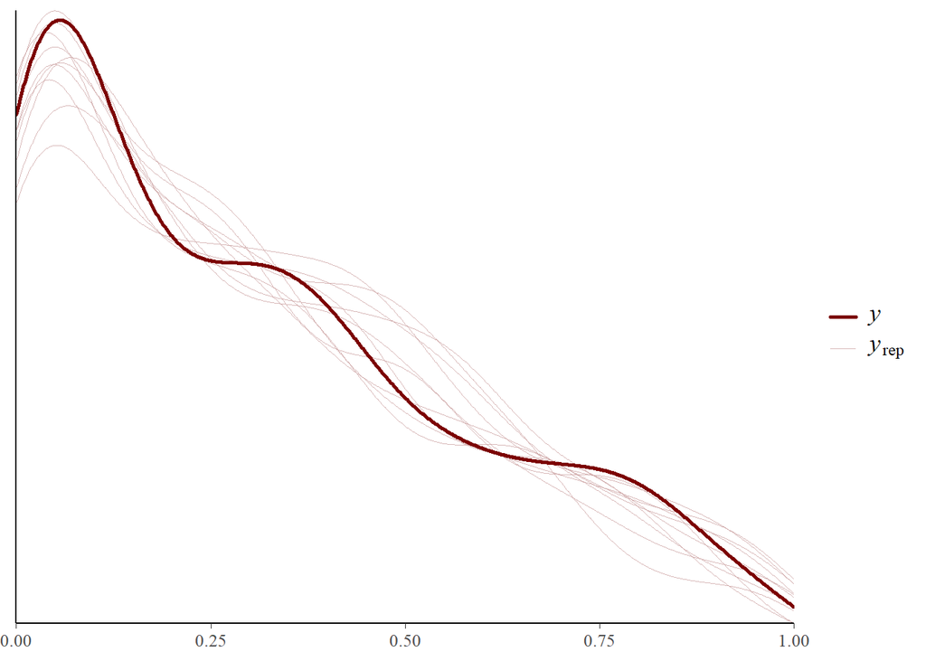

```r
# posterior predictive checks
pp_check(shrimp_out_model)
```

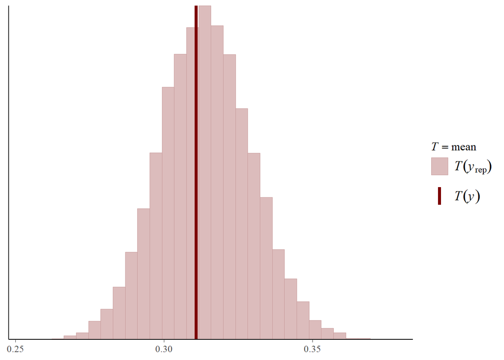

```r
pp_check(shrimp_out_model, type = "stat", stat = "mean")
```

```r
summary(fitted(shrimp_out_model))
```

```
##     Estimate         Est.Error            Q2.5              Q97.5
##  Min.   :0.05903   Min.   :0.04699   Min.   :0.001233   Min.   :0.2260
##  1st Qu.:0.19328   1st Qu.:0.08172   1st Qu.:0.070745   1st Qu.:0.3942
##  Median :0.30089   Median :0.09558   Median :0.124544   Median :0.5096
##  Mean   :0.31422   Mean   :0.09622   Mean   :0.145423   Mean   :0.5181
##  3rd Qu.:0.41508   3rd Qu.:0.10873   3rd Qu.:0.203817   3rd Qu.:0.6305
##  Max.   :0.70428   Max.   :0.18746   Max.   :0.454831   Max.   :0.8784
```

To compare with a summary of the predicted data, they seem to align very nicely.

```r
summary(predict(shrimp_out_model))
```

```
##     Estimate         Est.Error           Q2.5               Q97.5
##  Min.   :0.05832   Min.   :0.1069   Min.   :0.0000000   Min.   :0.3848
##  1st Qu.:0.19378   1st Qu.:0.1951   1st Qu.:0.0000000   1st Qu.:0.7228
##  Median :0.30144   Median :0.2232   Median :0.0000000   Median :0.8433
##  Mean   :0.31431   Mean   :0.2262   Mean   :0.0008017   Mean   :0.8165
##  3rd Qu.:0.41502   3rd Qu.:0.2542   3rd Qu.:0.0000000   3rd Qu.:0.9289
##  Max.   :0.70080   Max.   :0.3974   Max.   :0.0472786   Max.   :1.0000
```

### 7.2.2 Posterior marginal effects

#### 7.2.2.1 Pairwise contrasts of stroke and stage

```r
shrimp_out_contrasts <- shrimp_out_model |>
    emmeans(~stroke * stage, epred = TRUE, re_formla = NULL, rg.limit = 14000) |>
    contrast(method = "revpairwise")

# Extract the relevant contrast information
shrimp_out_contrasts <- as.data.frame(shrimp_out_contrasts) |>
    dplyr::filter(contrast %in% c("control Pre - 2 Pre", "control Pre - 4 Pre", "4 Pre - 2 Pre",
        "control Pre - control During", "control Pre - control Post", "4 Pre - 4 During",
        "4 Pre - 4 Post", "2 Pre - 2 During", "2 Pre - 2 Post"))

shrimp_out_contrasts
```

```
##  contrast                        estimate   lower.HPD  upper.HPD
##  2 Pre - 2 During              0.11124122  0.02991038 0.19526550
##  2 Pre - 2 Post                0.08161274 -0.00327231 0.16563823
##  4 Pre - 4 During              0.07146775 -0.03455554 0.18276195
##  4 Pre - 4 Post                0.00424298 -0.10889323 0.11883239
##  4 Pre - 2 Pre                 0.00831290 -0.10911805 0.14158252
##  control Pre - control During  0.02438722 -0.06822417 0.11723333
##  control Pre - control Post   -0.02058155 -0.11291257 0.06807063
##  control Pre - 2 Pre          -0.01089037 -0.13110502 0.11234895
##  control Pre - 4 Pre          -0.01896972 -0.15203909 0.11329580
##
## Results are averaged over the levels of: shrimp_number, goby_number, shrimp_species
## Point estimate displayed: median
## HPD interval probability: 0.95
```

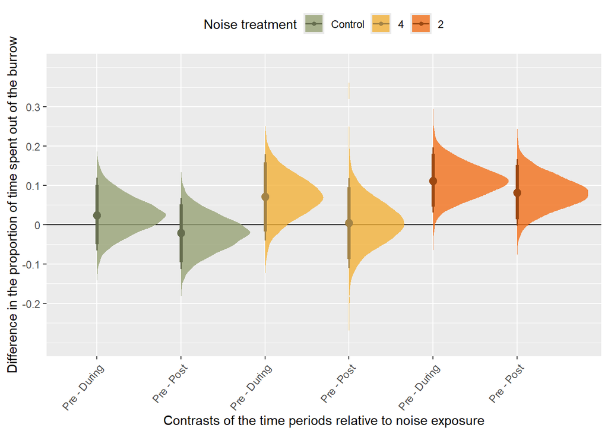

```r
shrimp_out_contrast_draws <- shrimp_out_model |>
    emmeans(~stroke * stage, epred = TRUE, re_formula = NA) |>
    contrast(method = "revpairwise") |>
    gather_emmeans_draws()

shrimp_out_temporal_contrasts <- shrimp_out_contrast_draws |>
    dplyr::filter(contrast %in% c("control Pre - control During", "control Pre - control Post",
        "4 Pre - 4 During", "4 Pre - 4 Post", "2 Pre - 2 During", "2 Pre - 2 Post")) |>
    mutate(stroke = ifelse(contrast %in% c("control Pre - control During", "control Pre - control Post"),
        "Control", ifelse(contrast %in% c("4 Pre - 4 During", "4 Pre - 4 Post"),
            "4", "2")))

shrimp_out_temporal_contrasts$stroke <- factor(shrimp_out_temporal_contrasts$stroke,
    levels = c("Control", "4", "2"))

shrimp_out_temporal_contrasts_fig <- ggplot(shrimp_out_temporal_contrasts, aes(x = .value,
    y = factor(contrast, levels = c("control Pre - control During", "control Pre - control Post",
        "4 Pre - 4 During", "4 Pre - 4 Post", "2 Pre - 2 During", "2 Pre - 2 Post")),
    color = stroke, fill = stroke)) + geom_vline(xintercept = 0, color = "black",
    size = 0.5) + stat_halfeye(.width = c(0.89, 0.95)) + scale_color_manual(values = c(colour11,
    colour12, colour13)) + scale_fill_manual(values = alpha(c(colour1, colour2, colour3),
    0.8)) + labs(x = "Difference in the proportion of time spent out of the burrow",
    y = "Contrasts of the time periods relative to noise exposure", fill = "Noise treatment",
    color = "Noise treatment", fill_ramp = "Credible interval") + coord_flip() +
    theme(legend.position = "top", axis.text.x = element_text(angle = 50, hjust = 1)) +
    scale_y_discrete(labels = c("Pre - During", "Pre - Post", "Pre - During", "Pre - Post",
        "Pre - During", "Pre - Post")) + scale_x_continuous(breaks = seq(-0.2, 0.3,
    0.1), labels = c("-0.2", "-0.1", "0", "0.1", "0.2", "0.3"), limits = c(-0.3,
    0.4))


shrimp_out_temporal_contrasts_fig
```

### 7.2.3 Extracting and plotting model estimates

#### 7.2.3.1 Extracting estimates

```r
shrimp_out_model_estimates <- shrimp_out_model |>
    emmeans(~stroke * stage, epred = TRUE, rg.limit = 14000, re_formula = NA)

shrimp_out_model_estimates <- as.data.frame(shrimp_out_model_estimates)

shrimp_out_model_estimates
```

```
##  stroke  stage     emmean lower.HPD upper.HPD
##  2       During 0.2088068 0.1219075 0.3118424
##  4       During 0.2589222 0.1546599 0.3916332
##  control During 0.2859898 0.1797559 0.4114104
##  2       Post   0.2386264 0.1385769 0.3589095
##  4       Post   0.3262621 0.1927346 0.4706111
##  control Post   0.3334816 0.2124747 0.4633444
##  2       Pre    0.3217096 0.1933117 0.4538872
##  4       Pre    0.3306229 0.1925348 0.4863961
##  control Pre    0.3110556 0.1939448 0.4440628
##
## Results are averaged over the levels of: shrimp_number, goby_number, shrimp_species
## Point estimate displayed: median
## HPD interval probability: 0.95
```

```r
# Storing the model estimate means for each group to plot later on
shrimp_out_model_estimates_control <- shrimp_out_model_estimates |>
    dplyr::filter(stroke == "control") |>
    rename(.value = emmean)

shrimp_out_model_estimates_four <- shrimp_out_model_estimates |>
    dplyr::filter(stroke == "4") |>
    rename(.value = emmean)

shrimp_out_model_estimates_two <- shrimp_out_model_estimates |>
    dplyr::filter(stroke == "2") |>
    rename(.value = emmean)
```

#### 7.2.3.2 Plotting model estimates and raw data

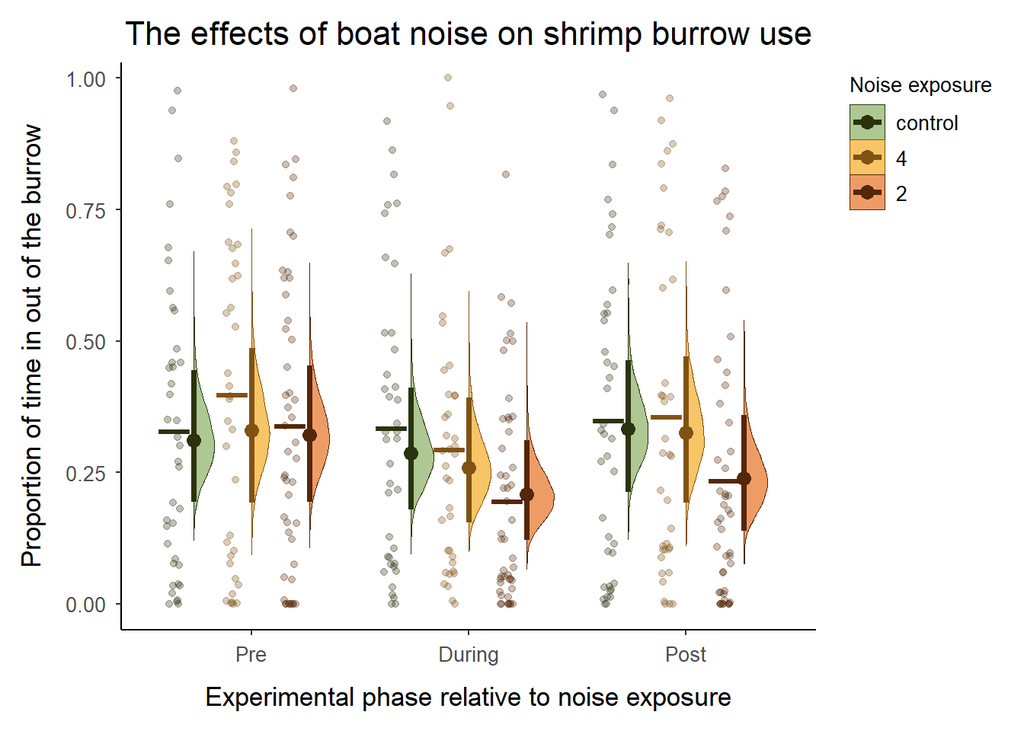

```r
shrimp_out_model_draws <- shrimp_out_model |>
    emmeans(~stroke * stage, epred = TRUE, rg.limit = 14000, re_formula = NA) |>
    gather_emmeans_draws()

shrimp_out_model_draws <- shrimp_out_model_draws |>
    rename(emmean = .value)

shrimp_out_raw_data <- final_df |>
    rename(emmean = shrimp_out)

shrimp_out_raw_data$stage <- factor(shrimp_out_raw_data$stage, levels = c("Pre",
    "During", "Post"))
shrimp_out_raw_data$stroke <- factor(shrimp_out_raw_data$stroke, levels = c("control",
    "4", "2"))

shrimp_out_model_estimates$stage <- factor(shrimp_out_model_estimates$stage, levels = c("Pre",
    "During", "Post"))
shrimp_out_model_estimates$stroke <- factor(shrimp_out_model_estimates$stroke, levels = c("control",
    "4", "2"))

shrimp_out_model_draws$stage <- factor(shrimp_out_model_draws$stage, levels = c("Pre",
    "During", "Post"))
shrimp_out_model_draws$stroke <- factor(shrimp_out_model_draws$stroke, levels = c("control",
    "4", "2"))

shrimp_out_means <- shrimp_out_raw_data |>
    group_by(stage, stroke) |>
    summarise(emmean = mean(emmean))


shrimp_out_fig_together <- ggplot(data = shrimp_out_raw_data, aes(x = stage, y = emmean,
    color = stroke, fill = stroke)) + geom_point(data = shrimp_out_means, alpha = 1,
    position = position_dodgenudge(width = 0.8, x = -0.09), size = 9, shape = "_") +
    geom_half_point(alpha = 0.3, position = position_dodgenudge(width = 0.8, x = -0.03),
        side = "l", range_scale = 0.5) + geom_half_violin(data = shrimp_out_model_draws,
    aes(x = stage, y = emmean, color = stroke, fill = stroke), alpha = 0.6, position = position_dodge(width = 0.8),
    side = "r", size = 0) + geom_point(data = shrimp_out_model_estimates, aes(x = stage,
    y = emmean, color = stroke), position = position_dodge(width = 0.8), size = 3) +
    geom_errorbar(data = shrimp_out_model_estimates, aes(x = stage, y = emmean, ymin = lower.HPD,
        ymax = upper.HPD, color = stroke), position = position_dodge(width = 0.8),
        width = 0, size = 1.25) + scale_fill_manual(values = c(control = "#76A34A",
    `4` = "#F29E00", `2` = "#E25A00"), name = "Noise exposure", guide = guide_legend(override.aes = list(size = 3))) +
    scale_color_manual(values = c(control = "#2A330E", `4` = "#805213", `2` = "#542709"),
        name = "Noise exposure", guide = guide_legend(override.aes = list(size = 3))) +
    scale_x_discrete(labels = c("Pre", "During", "Post")) + labs(title = "The effects of boat noise on shrimp burrow use",
    y = "Proportion of time in out of the burrow", x = "Experimental phase relative to noise exposure") +
    theme_classic() + theme(axis.text.x = element_text(size = 10, margin = margin(t = 5)),
    axis.text.y = element_text(size = 10, margin = margin(r = 5)), axis.title.x = element_text(size = 13,
        margin = margin(t = 10)), axis.title.y = element_text(size = 13, margin = margin(r = 10)),
    legend.text = element_text(size = 10), legend.title = element_text(size = 10),
    legend.position = "right", legend.justification = "top", plot.title = element_text(hjust = 0.5,
        size = 16), plot.margin = margin(10, 10, 10, 10))

shrimp_out_fig_together
```

#### 7.2.3.3 Plotting control estimates and raw data

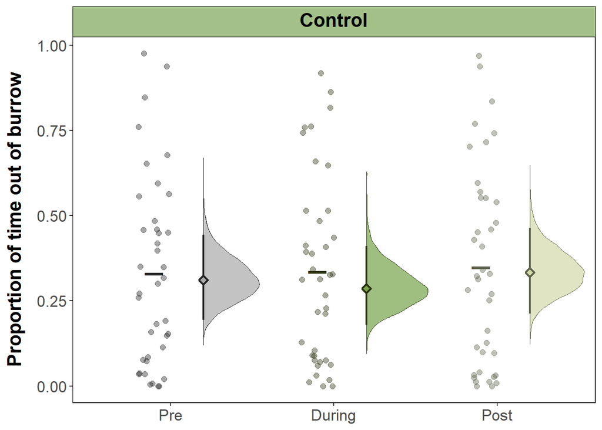

```r
shrimp_out_model_draws <- shrimp_out_model |>
    emmeans(~stroke * stage, epred = TRUE, rg.limit = 14000, re_formula = NA) |>
    gather_emmeans_draws()

shrimp_out_raw_data <- final_df |>
    rename(.value = shrimp_out)

shrimp_out_model_draws$stage <- factor(shrimp_out_model_draws$stage, levels = c("Pre",
    "During", "Post"))
shrimp_out_model_draws$stroke <- factor(shrimp_out_model_draws$stroke, levels = c("control",
    "4", "2"))

shrimp_out_control_model_draws <- shrimp_out_model_draws |>
    dplyr::filter(stroke == "control")

shrimp_control_raw_data <- final_df |>
    dplyr::filter(stroke == "control") |>
    rename(.value = shrimp_out)

shrimp_control_means <- shrimp_control_raw_data |>
    group_by(stage) |>
    summarise(.value = mean(.value))

shrimp_control_raw_data$stage <- factor(shrimp_control_raw_data$stage, levels = c("Pre",
    "During", "Post"))

# assigning a value for the baseline mean
shrimp_out_model_estimates_control_intercept <- shrimp_out_model_estimates_control %>%
    dplyr::filter(stage == "Pre") %>%
    pull(.value)

shrimp_out_fig_control <- ggplot(shrimp_control_raw_data, aes(y = .value, x = stage,
    fill = stage, color = stage)) + geom_half_violin(data = shrimp_out_control_model_draws,
    alpha = 0.7, size = 0, side = "r", position = position_nudge(x = 0.2)) + geom_jitter(position = position_jitternudge(x = -0.1,
    width = 0.1, nudge.from = "jittered"), alpha = 0.4, size = 2) + geom_crossbar(alpha = 0.6,
    size = 0.8, data = shrimp_out_model_estimates_control, aes(ymin = lower.HPD,
        ymax = upper.HPD), width = 0, position = position_nudge(x = 0.2)) + geom_point(pch = 23,
    stroke = 1.2, data = shrimp_out_model_estimates_control, size = 2, position = position_nudge(x = 0.2)) +
    geom_point(data = shrimp_control_means, position = position_dodgenudge(width = 0.8,
        x = -0.1), size = 9, shape = "_") + labs(x = "Period relative to treatment",
    y = "Proportion of time out of burrow") + theme(legend.position = "none", axis.title.x = element_blank(),
    axis.text.x = element_text(size = 13), axis.text.y = element_text(size = 13),
    panel.grid = element_blank(), axis.title.y = element_text(size = 16, face = "bold",
        margin = margin(t = 0, b = 0, l = 0, r = 10)), plot.title = element_textbox_simple(face = "bold",
        size = 16, halign = 0.5, linewidth = 0.3, linetype = 1, color = "black",
        fill = "#A3C088", padding = margin(5, 5, 5, 5)), panel.background = element_rect(fill = "white",
        colour = "black"), plot.background = element_rect(fill = NA, colour = NA)) +
    ggtitle("Control") + scale_fill_manual(values = c(Pre = "darkgrey", During = "#76A34A",
    Post = "#D3D9A7")) + scale_color_manual(values = c(Pre = "#242424", During = "#2A330E",
    Post = "#5d634c"))

shrimp_out_fig_control
```

#### 7.2.3.4 Plotting 4-stroke estimates and raw data

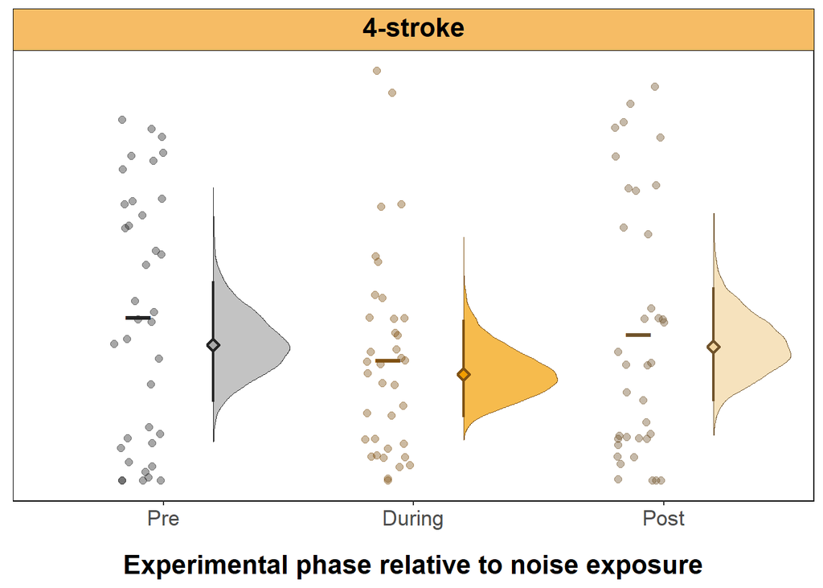

```r
shrimp_out_control_model_draws <- shrimp_out_model_draws |>
    dplyr::filter(stroke == "4")

shrimp_four_raw_data <- final_df |>
    dplyr::filter(stroke == "4") |>
    rename(.value = shrimp_out)

shrimp_four_raw_data$stage <- factor(shrimp_four_raw_data$stage, levels = c("Pre",
    "During", "Post"))

shrimp_four_means <- shrimp_four_raw_data |>
    group_by(stage) |>
    summarise(.value = mean(.value))

shrimp_out_fig_four <- ggplot(shrimp_four_raw_data, aes(y = .value, x = stage, fill = stage,
    color = stage)) + geom_half_violin(data = shrimp_out_control_model_draws, alpha = 0.7,
    size = 0, side = "r", position = position_nudge(x = 0.2)) + geom_jitter(position = position_jitternudge(x = -0.1,
    width = 0.1, nudge.from = "jittered"), alpha = 0.4, size = 2) + geom_crossbar(alpha = 0.6,
    size = 0.8, data = shrimp_out_model_estimates_four, aes(ymin = lower.HPD, ymax = upper.HPD),
    width = 0, position = position_nudge(x = 0.2)) + geom_point(pch = 23, stroke = 1.2,
    data = shrimp_out_model_estimates_four, size = 2, position = position_nudge(x = 0.2)) +
    geom_point(data = shrimp_four_means, position = position_dodgenudge(width = 0.8,
        x = -0.1), size = 9, shape = "_") + xlab("Experimental phase relative to noise exposure") +
    theme(legend.position = "none", axis.title.y = element_blank(), axis.text.x = element_text(size = 13),
        axis.text.y = element_blank(), axis.ticks.y = element_blank(), panel.grid = element_blank(),
        axis.title.x = element_text(size = 16, face = "bold", margin = margin(t = 15,
            b = 0, l = 0, r = 0)), plot.title = element_textbox_simple(face = "bold",
            size = 16, halign = 0.5, linewidth = 0.3, linetype = 1, color = "black",
            fill = "#F6BC65", padding = margin(5, 5, 5, 5)), panel.background = element_rect(fill = "white",
            colour = "black"), plot.background = element_rect(fill = NA, colour = NA)) +
    ggtitle("4-stroke") + scale_fill_manual(values = c(Pre = "darkgrey", During = "#F29E00",
    Post = "#F2D5A0")) + scale_color_manual(values = c(Pre = "#242424", During = "#805213",
    Post = "#70532b"))

shrimp_out_fig_four
```

#### 7.2.3.5 Plotting 2-stroke estimates and raw data

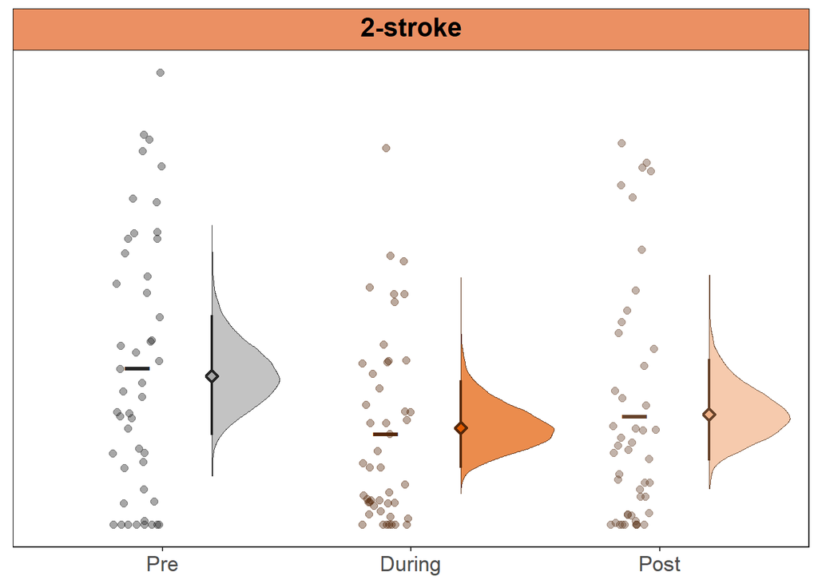

```r
shrimp_out_control_model_draws <- shrimp_out_model_draws |>
    dplyr::filter(stroke == "2")

shrimp_two_raw_data <- final_df |>
    dplyr::filter(stroke == "2") |>
    rename(.value = shrimp_out)

shrimp_two_raw_data$stage <- factor(shrimp_two_raw_data$stage, levels = c("Pre",
    "During", "Post"))

shrimp_two_means <- shrimp_two_raw_data |>
    group_by(stage) |>
    summarise(.value = mean(.value))

shrimp_out_fig_two <- ggplot(shrimp_two_raw_data, aes(y = .value, x = stage, fill = stage,
    color = stage)) + geom_half_violin(data = shrimp_out_control_model_draws, alpha = 0.7,
    size = 0, side = "r", position = position_nudge(x = 0.2)) + geom_jitter(position = position_jitternudge(x = -0.1,
    width = 0.1, nudge.from = "jittered"), alpha = 0.4, size = 2) + geom_crossbar(alpha = 0.6,
    size = 0.8, data = shrimp_out_model_estimates_two, aes(ymin = lower.HPD, ymax = upper.HPD),
    width = 0, position = position_nudge(x = 0.2)) + geom_point(pch = 23, stroke = 1.2,
    data = shrimp_out_model_estimates_two, size = 2, position = position_nudge(x = 0.2)) +
    geom_point(data = shrimp_two_means, position = position_dodgenudge(width = 0.8,
        x = -0.1), size = 9, shape = "_") + theme(legend.position = "none", axis.title.x = element_blank(),
    axis.text.x = element_text(size = 13), axis.title.y = element_blank(), axis.text.y = element_blank(),
    axis.ticks.y = element_blank(), panel.grid = element_blank(), plot.title = element_textbox_simple(face = "bold",
        size = 16, halign = 0.5, linewidth = 0.3, linetype = 1, color = "black",
        fill = "#EB9063", padding = margin(5, 5, 5, 5)), panel.background = element_rect(fill = "white",
        colour = "black"), plot.background = element_rect(fill = NA, colour = NA)) +
    ggtitle("2-stroke") + scale_fill_manual(values = c(Pre = "darkgrey", During = "#E25A00",
    Post = "#F2B389")) + scale_color_manual(values = c(Pre = "#242424", During = "#542709",
    Post = "#66422a"))

shrimp_out_fig_two
```

#### 7.2.3.6 Combining plots into one figure

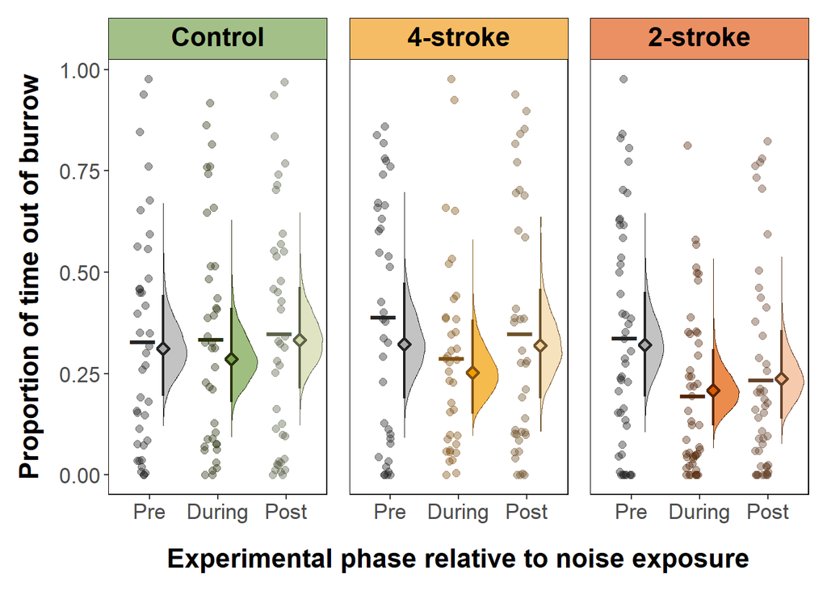

```r
shrimp_out_plot3 <- shrimp_out_fig_control + shrimp_out_fig_four + shrimp_out_fig_two +
    plot_layout(ncol = 3)

shrimp_out_plot3
```

```r
ggsave("./3-figs/shrimp_out_plot3.jpeg", plot = shrimp_out_plot3, units = "px", width = 2200,
    height = 1400, dpi = 300)
ggsave("./3-figs/shrimp_out_plot3.pdf", plot = shrimp_out_plot3, units = "px", width = 2200,
    height = 1400)
```

### 7.2.4 Effects of covariates on the proportion of time shrimp spent outside of the burrow

#### 7.2.4.1 Goby number

```r
shrimp_out_goby_number_contrasts <- shrimp_out_model |>
    emmeans(~goby_number, epred = TRUE, re_formla = NULL, rg.limit = 14000) |>
    contrast(method = "revpairwise")

shrimp_out_goby_number_contrasts
```

```
##  contrast                    estimate lower.HPD upper.HPD
##  goby_number2 - goby_number1   0.0667    -0.019      0.16
##
## Results are averaged over the levels of: stroke, stage, shrimp_number, shrimp_species
## Point estimate displayed: median
## HPD interval probability: 0.95
```

#### 7.2.4.2 Shrimp number

```r
shrimp_out_shrimp_number_contrasts <- shrimp_out_model |>
    emmeans(~shrimp_number, epred = TRUE, re_formla = NULL, rg.limit = 14000) |>
    contrast(method = "revpairwise")

shrimp_out_shrimp_number_contrasts <- as.data.frame(shrimp_out_shrimp_number_contrasts)

shrimp_out_shrimp_number_estimates <- shrimp_out_model |>
    emmeans(~shrimp_number, epred = TRUE, re_formla = NULL, rg.limit = 14000)

shrimp_out_shrimp_number_estimates
```

```
##  shrimp_number emmean lower.HPD upper.HPD
##  1              0.223     0.129     0.329
##  2              0.339     0.262     0.433
##  3              0.308     0.124     0.534
##
## Results are averaged over the levels of: stroke, stage, goby_number, shrimp_species
## Point estimate displayed: median
## HPD interval probability: 0.95
```

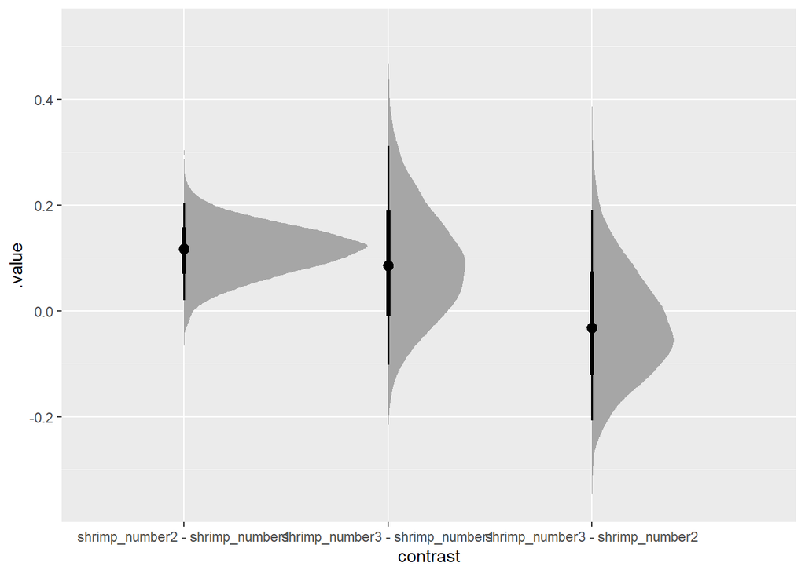

```r
shrimp_out_shrimp_number_contrast_draws <- shrimp_out_model |>
    emmeans(~shrimp_number, epred = TRUE, re_formla = NULL, rg.limit = 14000) |>
    contrast(method = "revpairwise") |>
    gather_emmeans_draws()

ggplot(data = shrimp_out_shrimp_number_contrast_draws, aes(x = contrast, y = .value)) +
    stat_halfeye()
```

#### Shrimp species

```r
shrimp_out_shrimp_species_contrasts <- shrimp_out_model |>
    emmeans(~shrimp_species, epred = TRUE, re_formla = NULL, rg.limit = 14000) |>
    contrast(method = "revpairwise")

shrimp_out_shrimp_species_contrasts
```

```
##  contrast               estimate lower.HPD upper.HPD
##  mannarensis - bellulus  0.00168   -0.1752    0.1547
##  sciolii - bellulus     -0.09937   -0.3017    0.0899
##  sciolii - mannarensis  -0.10302   -0.2208    0.0390
##  unknown - bellulus     -0.01135   -0.2049    0.1599
##  unknown - mannarensis  -0.01330   -0.1033    0.0914
##  unknown - sciolii       0.08881   -0.0588    0.2365
##
## Results are averaged over the levels of: stroke, stage, shrimp_number, goby_number
## Point estimate displayed: median
## HPD interval probability: 0.95
```

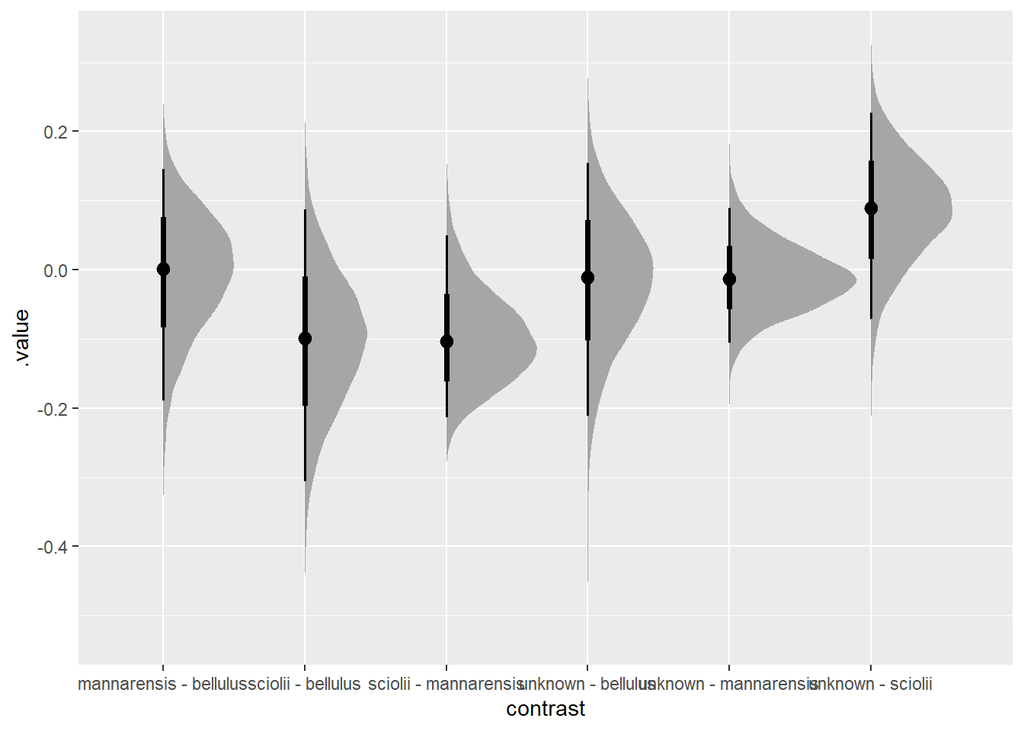

```r
shrimp_out_shrimp_species_contrasts_draws <- shrimp_out_model |>
    emmeans(~shrimp_species, epred = TRUE, re_formla = NULL, rg.limit = 14000) |>
    contrast(method = "revpairwise") |>
    gather_emmeans_draws()

ggplot(data = shrimp_out_shrimp_species_contrasts_draws, aes(x = contrast, y = .value)) +
    stat_halfeye()
```

## 7.3 🐟-🦐 Modelling the proportion of time shrimp spent in contact with the goby

### 7.3.1 Checking the response variable distribution

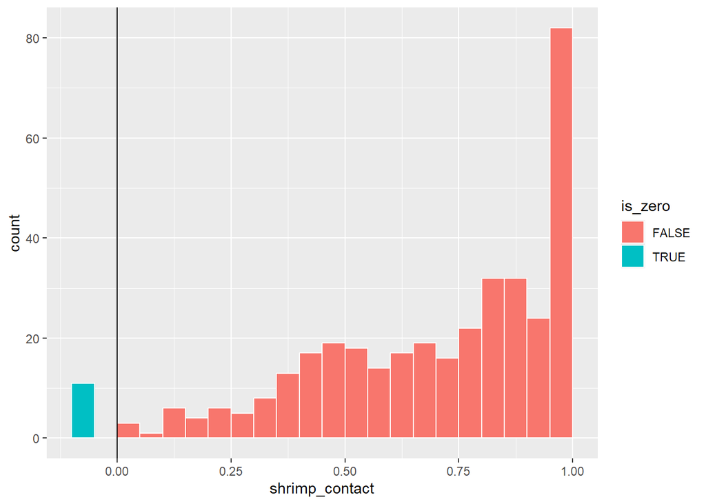

```r
shrimp_contact_df <- final_df |>
    mutate(is_zero = shrimp_contact == 0)

shrimp_contact_plot <- shrimp_contact_df |>
    mutate(shrimp_contact = ifelse(is_zero, -0.1, shrimp_contact)) |>
    ggplot(aes(x = shrimp_contact)) + geom_histogram(aes(fill = is_zero), binwidth = 0.05,
    boundary = 0, color = "white") + geom_vline(xintercept = 0)
shrimp_contact_plot
```

```r
# Distribution is a zero-one inflated beta distribution, because the value for
# shrimp_contact is bounded by 0-1 as it is a proportion of the total time and
# there is values of 0 and 1.
```

### 7.3.2 Running the model

```r
shrimp_contact_model <- brm(bf(shrimp_contact ~ stroke * stage + shrimp_number +
    goby_number + shrimp_species + (1 | site/burrow), phi ~ stroke * stage + shrimp_number +
    goby_number + shrimp_species + (1 | site/burrow), zoi ~ stroke * stage + shrimp_number +
    goby_number + shrimp_species + (1 | site/burrow), coi ~ stroke * stage + shrimp_number +
    goby_number + shrimp_species + (1 | site/burrow)), data = final_df, prior = priors,
    family = zero_one_inflated_beta(), control = list(adapt_delta = 0.99, max_treedepth = 12),
    chains = 4, iter = 6000, warmup = 1000, seed = 1, backend = "cmdstanr", cores = 4,
    threads = threading(2), file = "shrimp_contact_model")

summary(shrimp_contact_model)
```

```
##  Family: zero_one_inflated_beta
##   Links: mu = logit; phi = log; zoi = logit; coi = logit
## Formula: shrimp_contact ~ stroke * stage + shrimp_number + goby_number + shrimp_species + (1 | site/burrow)
##          phi ~ stroke * stage + shrimp_number + goby_number + shrimp_species + (1 | site/burrow)
##          zoi ~ stroke * stage + shrimp_number + goby_number + shrimp_species + (1 | site/burrow)
##          coi ~ stroke * stage + shrimp_number + goby_number + shrimp_species + (1 | site/burrow)
##    Data: final_df (Number of observations: 369)
##   Draws: 4 chains, each with iter = 6000; warmup = 1000; thin = 1;
##          total post-warmup draws = 20000
##
## Multilevel Hyperparameters:
## ~site (Number of levels: 5)
##                   Estimate Est.Error l-95% CI u-95% CI Rhat Bulk_ESS Tail_ESS
## sd(Intercept)         0.31      0.28     0.01     1.01 1.00     4422     6853
## sd(phi_Intercept)     0.29      0.28     0.01     0.99 1.00     5122     6538
## sd(zoi_Intercept)     1.20      0.86     0.08     3.34 1.00     5704     6800
## sd(coi_Intercept)     2.44      1.97     0.09     7.26 1.00     7853     7421
##
## ~site:burrow (Number of levels: 123)
##                   Estimate Est.Error l-95% CI u-95% CI Rhat Bulk_ESS Tail_ESS
## sd(Intercept)         0.81      0.10     0.63     1.01 1.00     4557     7393
## sd(phi_Intercept)     0.70      0.17     0.37     1.03 1.00     3649     4764
## sd(zoi_Intercept)     2.66      0.61     1.64     4.04 1.00     6766    11703
## sd(coi_Intercept)     7.19      3.93     2.17    16.86 1.00     8258     8479
##
## Regression Coefficients:
##                               Estimate Est.Error l-95% CI u-95% CI Rhat
## Intercept                         0.79      0.55    -0.25     1.89 1.00
## phi_Intercept                     1.12      0.67    -0.19     2.47 1.00
## zoi_Intercept                    -4.78      1.94    -8.72    -1.11 1.00
## coi_Intercept                     1.38      3.94    -5.97     9.56 1.00
## stroke4                           0.65      0.29     0.09     1.22 1.00
## strokecontrol                     0.29      0.28    -0.26     0.83 1.00
## stagePost                         0.26      0.18    -0.09     0.62 1.00
## stagePre                          0.12      0.17    -0.21     0.46 1.00
## shrimp_number2                   -0.29      0.26    -0.79     0.21 1.00
## shrimp_number3                   -0.44      0.59    -1.61     0.73 1.00
## goby_number2                      0.09      0.25    -0.40     0.57 1.00
## shrimp_speciesmannarensis         0.06      0.46    -0.86     0.97 1.00
## shrimp_speciessciolii            -0.74      0.58    -1.89     0.37 1.00
```

[output cut: 97 more lines]

```
## coi_stagePre                     20406    15606
## coi_shrimp_number2               18466    14794
## coi_shrimp_number3               36617    14014
## coi_goby_number2                 24408    16540
## coi_shrimp_speciesmannarensis    24686    15542
## coi_shrimp_speciessciolii        34026    15571
## coi_shrimp_speciesunknown        24079    14807
## coi_stroke4:stagePost            28690    16315
## coi_strokecontrol:stagePost      26483    15080
## coi_stroke4:stagePre             23479    15804
## coi_strokecontrol:stagePre       25369    14685
##
## Draws were sampled using sample(hmc). For each parameter, Bulk_ESS
## and Tail_ESS are effective sample size measures, and Rhat is the potential
## scale reduction factor on split chains (at convergence, Rhat = 1).
```

### 7.3.3 Model fit and diagnostics

#### 7.3.3.1 Model convergence

```r
extract_rhats(shrimp_contact_model)
```

```
##                                    Rhat
## Intercept                     1.0005227
## phi_Intercept                 1.0001435
## zoi_Intercept                 0.9999331
## coi_Intercept                 1.0000882
## stroke4                       1.0004395
## strokecontrol                 1.0003713
## stagePost                     0.9999568
## stagePre                      1.0002299
## shrimp_number2                1.0007670
## shrimp_number3                1.0004739
## goby_number2                  1.0003800
## shrimp_speciesmannarensis     1.0003644
## shrimp_speciessciolii         1.0003243
## shrimp_speciesunknown         1.0003862
## stroke4:stagePost             0.9999707
## strokecontrol:stagePost       1.0000321
## stroke4:stagePre              1.0000330
## strokecontrol:stagePre        1.0000546
## phi_stroke4                   1.0002337
## phi_strokecontrol             1.0001813
## phi_stagePost                 1.0001259
## phi_stagePre                  0.9998986
## phi_shrimp_number2            1.0002640
## phi_shrimp_number3            1.0003272
## phi_goby_number2              1.0001709
## phi_shrimp_speciesmannarensis 1.0003540
## phi_shrimp_speciessciolii     1.0001288
## phi_shrimp_speciesunknown     1.0001611
## phi_stroke4:stagePost         1.0001231
## phi_strokecontrol:stagePost   1.0001511
## phi_stroke4:stagePre          1.0000056
## phi_strokecontrol:stagePre    0.9999452
## zoi_stroke4                   1.0003425
## zoi_strokecontrol             1.0000268
## zoi_stagePost                 1.0002708
## zoi_stagePre                  1.0003081
## zoi_shrimp_number2            1.0001342
## zoi_shrimp_number3            1.0002038
## zoi_goby_number2              1.0003639
```

[output cut: 14 more lines]

```
## coi_shrimp_speciesmannarensis 0.9999856
## coi_shrimp_speciessciolii     1.0002105
## coi_shrimp_speciesunknown     1.0001963
## coi_stroke4:stagePost         1.0004001
## coi_strokecontrol:stagePost   1.0001634
## coi_stroke4:stagePre          1.0001430
## coi_strokecontrol:stagePre    1.0000101
## site.sd(Intercept)            1.0004136
## site.sd(phi_Intercept)        1.0005560
## site.sd(zoi_Intercept)        1.0005406
## site.sd(coi_Intercept)        1.0001427
## site:burrow.sd(Intercept)     1.0003338
## site:burrow.sd(phi_Intercept) 1.0008470
## site:burrow.sd(zoi_Intercept) 1.0001670
## site:burrow.sd(coi_Intercept) 1.0002173
```

#### 7.3.3.2 Model fit

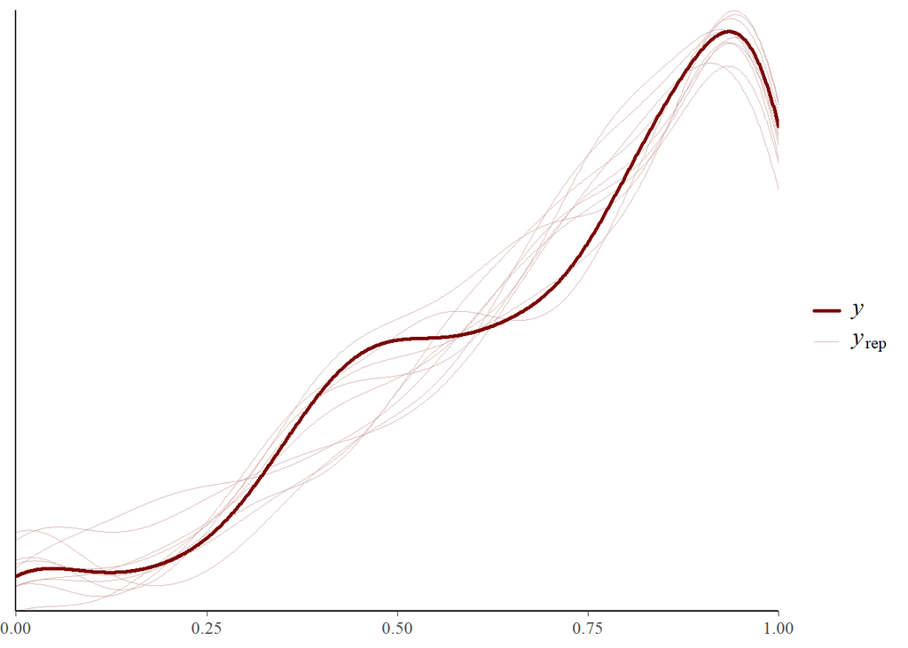

```r
# posterior predictive checks
pp_check(shrimp_contact_model)
```

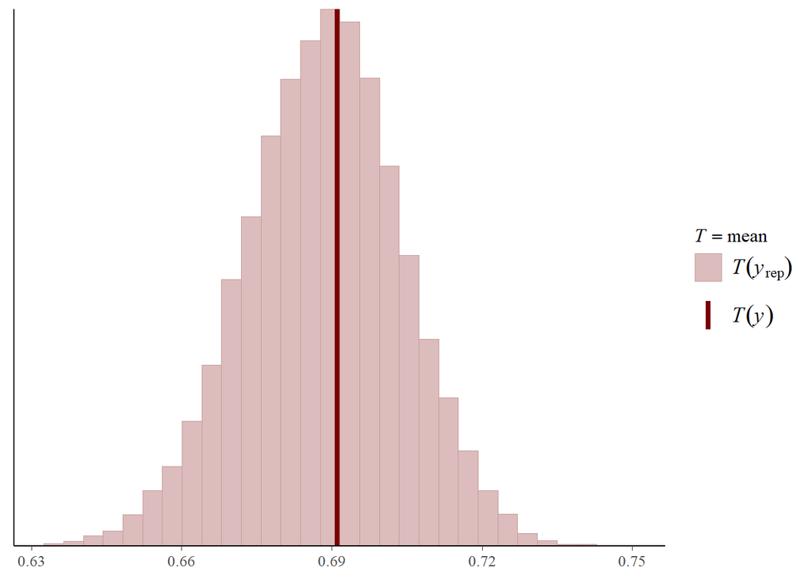

```r
pp_check(shrimp_contact_model, type = "stat", stat = "mean")
```

```r
summary(fitted(shrimp_contact_model))
```

```
##     Estimate        Est.Error            Q2.5             Q97.5
##  Min.   :0.2926   Min.   :0.06588   Min.   :0.03164   Min.   :0.5580
##  1st Qu.:0.5898   1st Qu.:0.08469   1st Qu.:0.35528   1st Qu.:0.7970
##  Median :0.7144   Median :0.09551   Median :0.48913   Median :0.8763
##  Mean   :0.6882   Mean   :0.10260   Mean   :0.46080   Mean   :0.8580
##  3rd Qu.:0.8059   3rd Qu.:0.10986   3rd Qu.:0.58302   3rd Qu.:0.9377
##  Max.   :0.9398   Max.   :0.22480   Max.   :0.73064   Max.   :0.9991
```

```r
summary(predict(shrimp_contact_model))
```

```
##     Estimate        Est.Error           Q2.5            Q97.5
##  Min.   :0.2912   Min.   :0.1456   Min.   :0.0000   Min.   :0.8383
##  1st Qu.:0.5868   1st Qu.:0.1917   1st Qu.:0.0103   1st Qu.:1.0000
##  Median :0.7142   Median :0.2166   Median :0.1106   Median :1.0000
##  Mean   :0.6882   Mean   :0.2308   Mean   :0.1324   Mean   :0.9941
##  3rd Qu.:0.8065   3rd Qu.:0.2527   3rd Qu.:0.2165   3rd Qu.:1.0000
##  Max.   :0.9395   Max.   :0.4509   Max.   :0.5404   Max.   :1.0000
```

### 7.3.4 Posterior marginal effects

#### 7.3.4.1 Pairwise contrasts of stroke and stage

```r
shrimp_contact_contrasts <- shrimp_contact_model |>
  emmeans(~ stroke*stage,
          epred = TRUE,
          re_formla = NULL,
          rg.limit =14000) |>
  contrast(method = "revpairwise")

overall_mean <- shrimp_contact_model |>
  emmeans(~ 1,             # 1 means "no factors," i.e. the grand mean
          epred = TRUE,    # estimate on the response scale
          re_formla = NULL,
          rg.limit = 14000)

# View the summary with posterior mean and credible intervals
overall_mean
```

```
##  1       emmean lower.HPD upper.HPD
##  overall  0.671     0.543     0.789
##
## Results are averaged over the levels of: stroke, stage, shrimp_number, goby_number, shrimp_species
## Point estimate displayed: median
## HPD interval probability: 0.95
```

```r
# Extract the relevant contrast information
shrimp_contact_contrasts <- as.data.frame(shrimp_contact_contrasts) |>
  dplyr::filter(contrast %in% c("control Pre - 2 Pre", "control Pre - 4 Pre","4 Pre - 2 Pre", "control Pre - control During", "control Pre - control Post", "4 Pre - 4 During", "4 Pre - 4 Post", "2 Pre - 2 During", "2 Pre - 2 Post"))

shrimp_contact_contrasts
```

```
##  contrast                        estimate   lower.HPD  upper.HPD
##  2 Pre - 2 During              0.02860599 -0.04343278 0.10629264
##  2 Pre - 2 Post               -0.02610253 -0.10486712 0.06071043
##  4 Pre - 4 During             -0.02770567 -0.12792281 0.07167053
##  4 Pre - 4 Post               -0.07128725 -0.16326137 0.01637126
##  4 Pre - 2 Pre                 0.07507622 -0.04516392 0.19730855
##  control Pre - control During  0.05412175 -0.03917928 0.15588585
##  control Pre - control Post    0.01348306 -0.08026895 0.10607465
##  control Pre - 2 Pre           0.09079625 -0.03019632 0.21535561
##  control Pre - 4 Pre           0.01527249 -0.11322530 0.14688317
##
## Results are averaged over the levels of: shrimp_number, goby_number, shrimp_species
## Point estimate displayed: median
## HPD interval probability: 0.95
```

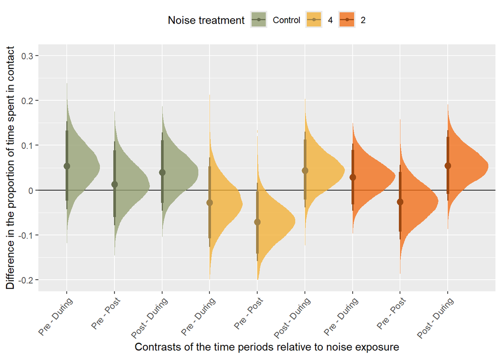

```r
shrimp_contact_contrasts_draws <- shrimp_contact_model |>
    emmeans(~stroke * stage, epred = TRUE, re_formula = NA) |>
    contrast(method = "revpairwise") |>
    gather_emmeans_draws()

shrimp_contact_temporal_contrasts <- shrimp_contact_contrasts_draws |>
    dplyr::filter(contrast %in% c("control Pre - control During", "control Pre - control Post",
        "control Post - control During", "4 Pre - 4 During", "4 Pre - 4 Post", "4 Post - 4 During",
        "2 Pre - 2 During", "2 Pre - 2 Post", "2 Post - 2 During")) |>
    mutate(stroke = ifelse(contrast %in% c("control Pre - control During", "control Pre - control Post",
        "control Post - control During"), "Control", ifelse(contrast %in% c("4 Pre - 4 During",
        "4 Pre - 4 Post", "4 Post - 4 During"), "4", "2")))

shrimp_contact_temporal_contrasts$stroke <- factor(shrimp_contact_temporal_contrasts$stroke,
    levels = c("Control", "4", "2"))

shrimp_contact_temporal_fig <- ggplot(shrimp_contact_temporal_contrasts, aes(x = .value,
    y = factor(contrast, levels = c("control Pre - control During", "control Pre - control Post",
        "control Post - control During", "4 Pre - 4 During", "4 Pre - 4 Post", "4 Post - 4 During",
        "2 Pre - 2 During", "2 Pre - 2 Post", "2 Post - 2 During")), color = stroke,
    fill = stroke)) + geom_vline(xintercept = 0, color = "black", size = 0.5) + stat_halfeye(.width = c(0.89,
    0.95)) + scale_color_manual(values = c(colour11, colour12, colour13)) + scale_fill_manual(values = alpha(c(colour1,
    colour2, colour3), 0.8)) + labs(x = "Difference in the proportion of time spent in contact",
    y = "Contrasts of the time periods relative to noise exposure", fill = "Noise treatment",
    color = "Noise treatment", fill_ramp = "Credible interval") + coord_flip() +
    theme(legend.position = "top", axis.text.x = element_text(angle = 50, hjust = 1)) +
    scale_y_discrete(labels = c("Pre - During", "Pre - Post", "Post - During", "Pre - During",
        "Pre - Post", "Post - During", "Pre - During", "Pre - Post", "Post - During")) +
    scale_x_continuous(breaks = seq(-0.2, 0.3, 0.1), labels = c("-0.2", "-0.1", "0",
        "0.1", "0.2", "0.3"), limits = c(-0.2, 0.3))


shrimp_contact_temporal_fig
```

### 7.3.5 Extracting and plotting model estimates

#### 7.3.5.1 Extracting estimates

```r
shrimp_contact_model_estimates <- shrimp_contact_model |>
    emmeans(~stroke * stage, epred = TRUE, rg.limit = 14000, re_formula = NA)

shrimp_contact_model |>
    emmeans(~1, epred = TRUE, rg.limit = 14000, re_formula = NA)
```

```
##  1       emmean lower.HPD upper.HPD
##  overall  0.671     0.543     0.789
##
## Results are averaged over the levels of: stroke, stage, shrimp_number, goby_number, shrimp_species
## Point estimate displayed: median
## HPD interval probability: 0.95
```

```r
shrimp_contact_model_estimates <- as.data.frame(shrimp_contact_model_estimates)

shrimp_contact_model_estimates
```

```
##  stroke  stage     emmean lower.HPD upper.HPD
##  2       During 0.5833632 0.4287101 0.7201552
##  4       During 0.7175983 0.5615712 0.8568383
##  control During 0.6488437 0.4991426 0.7897400
##  2       Post   0.6397286 0.4872690 0.7778386
##  4       Post   0.7623786 0.6225847 0.8801669
##  control Post   0.6905964 0.5467257 0.8199855
##  2       Pre    0.6127777 0.4593987 0.7542849
##  4       Pre    0.6893009 0.5230593 0.8280634
##  control Pre    0.7050247 0.5548278 0.8339999
##
## Results are averaged over the levels of: shrimp_number, goby_number, shrimp_species
## Point estimate displayed: median
## HPD interval probability: 0.95
```

```r
# Storing the model estimate means for each group to plot later on
shrimp_contact_model_estimates_control <- shrimp_contact_model_estimates |>
    dplyr::filter(stroke == "control") |>
    rename(.value = emmean)

shrimp_contact_model_estimates_four <- shrimp_contact_model_estimates |>
    dplyr::filter(stroke == "4") |>
    rename(.value = emmean)

shrimp_contact_model_estimates_two <- shrimp_contact_model_estimates |>
    dplyr::filter(stroke == "2") |>
    rename(.value = emmean)
```

#### 7.3.5.2 Plotting model estimates and raw data

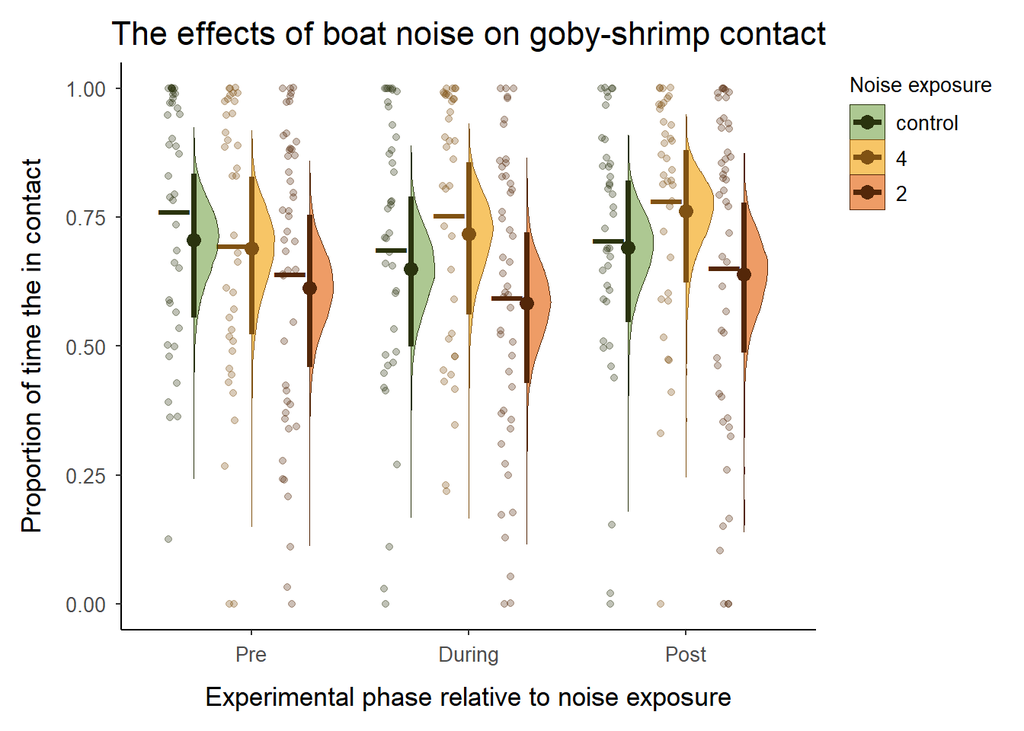

```r
shrimp_contact_model_draws <- shrimp_contact_model |>
    emmeans(~stroke * stage, epred = TRUE, rg.limit = 14000, re_formula = NA) |>
    gather_emmeans_draws()

shrimp_contact_model_draws <- shrimp_contact_model_draws |>
    rename(emmean = .value)

shrimp_contact_raw_data <- final_df |>
    rename(emmean = shrimp_contact)

shrimp_contact_raw_data$stage <- factor(shrimp_contact_raw_data$stage, levels = c("Pre",
    "During", "Post"))
shrimp_contact_raw_data$stroke <- factor(shrimp_contact_raw_data$stroke, levels = c("control",
    "4", "2"))

shrimp_contact_model_estimates$stage <- factor(shrimp_contact_model_estimates$stage,
    levels = c("Pre", "During", "Post"))
shrimp_contact_model_estimates$stroke <- factor(shrimp_contact_model_estimates$stroke,
    levels = c("control", "4", "2"))

shrimp_contact_model_draws$stage <- factor(shrimp_contact_model_draws$stage, levels = c("Pre",
    "During", "Post"))
shrimp_contact_model_draws$stroke <- factor(shrimp_contact_model_draws$stroke, levels = c("control",
    "4", "2"))

shrimp_contact_means <- shrimp_contact_raw_data |>
    group_by(stage, stroke) |>
    summarise(emmean = mean(emmean))


shrimp_contact_fig_together <- ggplot(data = shrimp_contact_raw_data, aes(x = stage,
    y = emmean, color = stroke, fill = stroke)) + geom_point(data = shrimp_contact_means,
    alpha = 1, position = position_dodgenudge(width = 0.8, x = -0.09), size = 9,
    shape = "_") + geom_half_point(alpha = 0.3, position = position_dodgenudge(width = 0.8,
    x = -0.03), side = "l", range_scale = 0.5) + geom_half_violin(data = shrimp_contact_model_draws,
    aes(x = stage, y = emmean, color = stroke, fill = stroke), alpha = 0.6, position = position_dodge(width = 0.8),
    side = "r", size = 0) + geom_point(data = shrimp_contact_model_estimates, aes(x = stage,
    y = emmean, color = stroke), position = position_dodge(width = 0.8), size = 3) +
    geom_errorbar(data = shrimp_contact_model_estimates, aes(x = stage, y = emmean,
        ymin = lower.HPD, ymax = upper.HPD, color = stroke), position = position_dodge(width = 0.8),
        width = 0, size = 1.25) + scale_fill_manual(values = c(control = "#76A34A",
    `4` = "#F29E00", `2` = "#E25A00"), name = "Noise exposure", guide = guide_legend(override.aes = list(size = 3))) +
    scale_color_manual(values = c(control = "#2A330E", `4` = "#805213", `2` = "#542709"),
        name = "Noise exposure", guide = guide_legend(override.aes = list(size = 3))) +
    scale_x_discrete(labels = c("Pre", "During", "Post")) + labs(title = "The effects of boat noise on goby-shrimp contact",
    y = "Proportion of time the in contact", x = "Experimental phase relative to noise exposure") +
    theme_classic() + theme(axis.text.x = element_text(size = 10, margin = margin(t = 5)),
    axis.text.y = element_text(size = 10, margin = margin(r = 5)), axis.title.x = element_text(size = 13,
        margin = margin(t = 10)), axis.title.y = element_text(size = 13, margin = margin(r = 10)),
    legend.text = element_text(size = 10), legend.title = element_text(size = 10),
    legend.position = "right", legend.justification = "top", plot.title = element_text(hjust = 0.5,
        size = 16), plot.margin = margin(10, 10, 10, 10))

shrimp_contact_fig_together
```

```r
ggsave("./3-figs/shrimp_contact_fig_together.png", plot = shrimp_contact_fig_together,
    units = "px", width = 2200, height = 1400, dpi = 300)
```

#### 7.3.5.3 Plotting control estimates and raw data

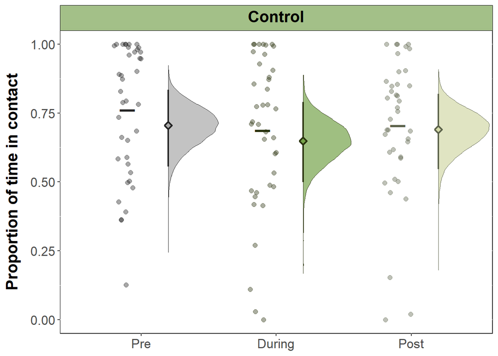

```r
shrimp_contact_model_draws <- shrimp_contact_model |>
    emmeans(~stroke * stage, epred = TRUE, rg.limit = 14000, re_formula = NA) |>
    gather_emmeans_draws()

shrimp_contact_raw_data <- final_df |>
    rename(.value = shrimp_contact)

shrimp_contact_model_draws$stage <- factor(shrimp_contact_model_draws$stage, levels = c("Pre",
    "During", "Post"))
shrimp_contact_model_draws$stroke <- factor(shrimp_contact_model_draws$stroke, levels = c("control",
    "4", "2"))

shrimp_contact_control_model_draws <- shrimp_contact_model_draws |>
    dplyr::filter(stroke == "control")

goby_control_raw_data <- final_df |>
    dplyr::filter(stroke == "control") |>
    rename(.value = shrimp_contact)

goby_control_means <- goby_control_raw_data |>
    group_by(stage) |>
    summarise(.value = mean(.value))

goby_control_raw_data$stage <- factor(goby_control_raw_data$stage, levels = c("Pre",
    "During", "Post"))

# assigning a value for the baseline mean
shrimp_contact_model_estimates_control_intercept <- shrimp_contact_model_estimates_control %>%
    dplyr::filter(stage == "Pre") %>%
    pull(.value)

shrimp_contact_fig_control <- ggplot(goby_control_raw_data, aes(y = .value, x = stage,
    fill = stage, color = stage)) + geom_half_violin(data = shrimp_contact_control_model_draws,
    alpha = 0.7, size = 0, side = "r", position = position_nudge(x = 0.2)) + geom_jitter(position = position_jitternudge(x = -0.1,
    width = 0.1, nudge.from = "jittered"), alpha = 0.4, size = 2) + geom_crossbar(alpha = 0.6,
    size = 0.8, data = shrimp_contact_model_estimates_control, aes(ymin = lower.HPD,
        ymax = upper.HPD), width = 0, position = position_nudge(x = 0.2)) + geom_point(pch = 23,
    stroke = 1.2, data = shrimp_contact_model_estimates_control, size = 2, position = position_nudge(x = 0.2)) +
    geom_point(data = goby_control_means, position = position_dodgenudge(width = 0.8,
        x = -0.1), size = 9, shape = "_") + labs(x = "Period relative to treatment",
    y = "Proportion of time in contact") + theme(legend.position = "none", axis.title.x = element_blank(),
    axis.text.x = element_text(size = 13), axis.text.y = element_text(size = 13),
    axis.title.y = element_text(size = 16, face = "bold", margin = margin(t = 0,
        b = 0, l = 0, r = 10)), plot.title = element_textbox_simple(face = "bold",
        size = 16, halign = 0.5, linewidth = 0.3, linetype = 1, color = "black",
        fill = "#A3C088", padding = margin(5, 5, 5, 5)), panel.background = element_rect(fill = "white",
        colour = "black"), plot.background = element_rect(fill = NA, colour = NA)) +
    ggtitle("Control") + scale_fill_manual(values = c(Pre = "darkgrey", During = "#76A34A",
    Post = "#D3D9A7")) + scale_color_manual(values = c(Pre = "#242424", During = "#2A330E",
    Post = "#5d634c"))

shrimp_contact_fig_control
```

#### 7.3.5.4 Plotting 4-stroke estimates and raw data

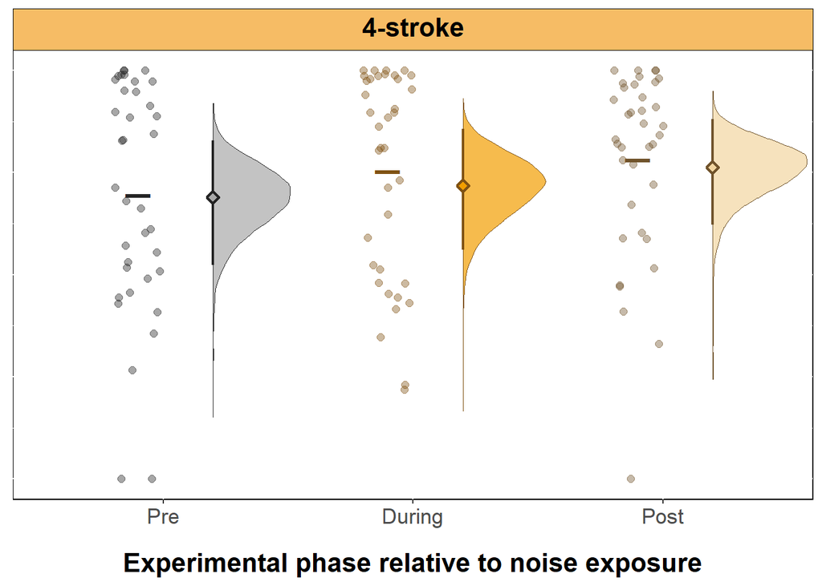

```r
shrimp_contact_control_model_draws <- shrimp_contact_model_draws |>
    dplyr::filter(stroke == "4")

goby_four_raw_data <- final_df |>
    dplyr::filter(stroke == "4") |>
    rename(.value = shrimp_contact)

goby_four_raw_data$stage <- factor(goby_four_raw_data$stage, levels = c("Pre", "During",
    "Post"))

goby_four_means <- goby_four_raw_data |>
    group_by(stage) |>
    summarise(.value = mean(.value))

shrimp_contact_fig_four <- ggplot(goby_four_raw_data, aes(y = .value, x = stage,
    fill = stage, color = stage)) + geom_half_violin(data = shrimp_contact_control_model_draws,
    alpha = 0.7, size = 0, side = "r", position = position_nudge(x = 0.2)) + geom_jitter(position = position_jitternudge(x = -0.1,
    width = 0.1, nudge.from = "jittered"), alpha = 0.4, size = 2) + geom_crossbar(alpha = 0.6,
    size = 0.8, data = shrimp_contact_model_estimates_four, aes(ymin = lower.HPD,
        ymax = upper.HPD), width = 0, position = position_nudge(x = 0.2)) + geom_point(pch = 23,
    stroke = 1.2, data = shrimp_contact_model_estimates_four, size = 2, position = position_nudge(x = 0.2)) +
    geom_point(data = goby_four_means, position = position_dodgenudge(width = 0.8,
        x = -0.1), size = 9, shape = "_") + xlab("Experimental phase relative to noise exposure") +
    theme(legend.position = "none", axis.title.y = element_blank(), axis.text.x = element_text(size = 13),
        axis.text.y = element_blank(), axis.ticks.y = element_blank(), axis.title.x = element_text(size = 16,
            face = "bold", margin = margin(t = 15, b = 0, l = 0, r = 0)), plot.title = element_textbox_simple(face = "bold",
            size = 16, halign = 0.5, linewidth = 0.3, linetype = 1, color = "black",
            fill = "#F6BC65", padding = margin(5, 5, 5, 5)), panel.background = element_rect(fill = "white",
            colour = "black"), plot.background = element_rect(fill = NA, colour = NA)) +
    ggtitle("4-stroke") + scale_fill_manual(values = c(Pre = "darkgrey", During = "#F29E00",
    Post = "#F2D5A0")) + scale_color_manual(values = c(Pre = "#242424", During = "#805213",
    Post = "#70532b"))

shrimp_contact_fig_four
```